# Bayesian Data Analysis 2

Author

Affiliation

Martial Foegel

Laboratoire de Linguistique Formelle

Published

January 11, 2026

The following analysis will be based on a real dataset that came from a recent experiment. Since this work is still pending publication, I will show all the steps but using a synthetic dataset made with the same structure as the real one, but not the same results.

## The dataset

This dataset is based on an experience which follows the Elicited Production Task paradigm. In this experiment, participants of 4 different age group (3, 4, 5 years old and adults) are shown a picture before hearing a sentence that wrongly characterise said picture (for example a picture with a boy and a girl, the boy having a ball in it’s hand, while hearing the sentence “the girl has the ball”). The element that doesn’t match between the picture and the sentence can be the object of the sentence, the indirect object, the adjunct or the subject. The participants have to comment on what doesn’t match by producing an answer which will be later categorized into different types of answer (like Sentence or Cleft).

```r
dt <- readRDS("synthetic_dt.rds")
```

What the data looks like now :

```r
head(dt)
```

|  | Participant | Item | Age_group | Condition | Answer_type |
| --- | --- | --- | --- | --- | --- |
| 1 | 1 | 1 | 3 y/o | Adjunct | Ident_Sentence |
| 2 | 1 | 2 | 3 y/o | Adjunct | Sentence |
| 3 | 1 | 3 | 3 y/o | Adjunct | Constituant |
| 4 | 1 | 4 | 3 y/o | Adjunct | Ident_Sentence |
| 5 | 1 | 5 | 3 y/o | Adjunct | Sentence |
| 6 | 1 | 6 | 3 y/o | Adjunct | Sentence |

## Statistiques descriptives

```r
summary(dt)
```

```
  Participant        Item       Age_group             Condition
 1      :  34   1      :  80   3 y/o :680   Adjunct        :800
 2      :  34   2      :  80   4 y/o :680   Direct_object  :800
 3      :  34   3      :  80   5 y/o :680   Indirect_object:320
 4      :  34   4      :  80   Adults:680   Subject        :800
 5      :  34   5      :  80
 6      :  34   6      :  80
 (Other):2516   (Other):2240
         Answer_type
 Cleft         :520
 Cleft_Attempt :155
 Constituant   :564
 Ident_Sentence: 86
 Other         :147
 Reduced_Cleft :320
 Sentence      :928
```

### Find the data structure

In our dataset, we have two sampling units or random variables : **Item** and **Participant**. We also have two independent or predictor variables, **Age_group** and **Condition** (i.e. direct object, indirect object, subject and adjunct), and one independent variable, also called a variable of interest or response variable, **Answer_type** (constituent, sentence, identification sentence, cleft, cleft attempt, reduced cleft and other).

```r
table(dt$Item, dt$Age_group)[1:5,]
```

```
    3 y/o 4 y/o 5 y/o Adults
  1    20    20    20     20
  2    20    20    20     20
  3    20    20    20     20
  4    20    20    20     20
  5    20    20    20     20
```

```r
table(dt$Item, dt$Condition)[1:5,]
```

```
    Adjunct Direct_object Indirect_object Subject
  1      80             0               0       0
  2      80             0               0       0
  3      80             0               0       0
  4      80             0               0       0
  5      80             0               0       0
```

Each item is seen by each age group, but each of those items is only presented in one condition.

```r
table(dt$Participant, dt$Age_group)[c(1:2, 20:22),]
```

```
     3 y/o 4 y/o 5 y/o Adults
  1     34     0     0      0
  2     34     0     0      0
  20    34     0     0      0
  21     0    34     0      0
  22     0    34     0      0
```

```r
table(dt$Participant, dt$Condition)[1:5,]
```

```
    Adjunct Direct_object Indirect_object Subject
  1      10            10               4      10
  2      10            10               4      10
  3      10            10               4      10
  4      10            10               4      10
  5      10            10               4      10
```

Each participant only belongs to one age group, but they do see all conditions (10 for condition Adjunct, Direct_object and Subject, 4 for Indirect_object)

This does imply a hierarchical data structure, to take into account during the analysis.

We end up with the following maximal model:

```r
model_formula <- Answer_type ~ Age_group * Condition +
  (1+Age_group|Item)+ (1+Condition|Participant)
```

### A note on the distribution of the response variable

`Answer_type` is a categorical variable that follows a categorical distribution.

```r
head(dt)
```

|  | Participant | Item | Age_group | Condition | Answer_type |
| --- | --- | --- | --- | --- | --- |
| 1 | 1 | 1 | 3 y/o | Adjunct | Ident_Sentence |
| 2 | 1 | 2 | 3 y/o | Adjunct | Sentence |
| 3 | 1 | 3 | 3 y/o | Adjunct | Constituant |
| 4 | 1 | 4 | 3 y/o | Adjunct | Ident_Sentence |
| 5 | 1 | 5 | 3 y/o | Adjunct | Sentence |
| 6 | 1 | 6 | 3 y/o | Adjunct | Sentence |

If we had something like below we would be in a multinomial distribution:

```r
head(table(dt$Participant, dt$Answer_type))
```

```
    Cleft Cleft_Attempt Constituant Ident_Sentence Other Reduced_Cleft Sentence
  1     7             0           4              2     7             3       11
  2     6             1           5              1     5             6       10
  3     4             1           2              3     3             6       15
  4     5             1           2              3     2             3       18
  5     6             1           3              2     5             4       13
  6     6             2           3              0     3             7       13
```

Those are linked distributions, the same way the Bernoulli and binomial distributions are linked, but the distinction is important to note in order to specify the right family in our Bayesian package *brms* later on.

## Inferential statistics

### Why did we go for a bayesian analysis ?

Analysis where the response variable is categorical are less developed than numerical or even binary ones (especially in their practical implementation like in R). And they are especially sparse when we have to take into account the hierarchical structure of our data.

We can do it relatively well when we don’t take into account the hierarchical structure (example below).

```r
summary(nnet::multinom(Answer_type ~ Age_group + Condition, data = dt))$coefficients[1:3, 1:3]
```

```
               (Intercept) Age_group4 y/o Age_group5 y/o
Cleft_Attempt   -2.1636807      0.7348101      0.7218762
Constituant     -0.6939487      1.0805800      1.3195855
Ident_Sentence  -0.8821599     -0.3979209     -0.4266283
```

But this becomes complicated when we add the random structure. I only found one package that was able to do random structure, but it doesn’t run with a complex structure like ours.

```r
mb_logit <- mclogit::mblogit(Answer_type ~ Age_group + Condition,
                data = dt,
                random=list(~1+Age_group|Item,
                            ~1+Condition|Participant))
```

This is most likely due to a combination of frequentist models not being able to support complex data structure for a categorical variable as well as the quasi-complete separation of our data (see “FAQ What Is Complete or Quasi-Complete Separation in Logistic/Probit Regression and How Do We Deal with Them?” (n.d.); Mansournia et al. (2018)). The second part happens when one of the categories of the answer variable has low frequencies overall or in some combination of the predictor variable (we have no answer of a specific type with some specific parameters cases which causes the quasi-complete separation). If I understood Albert and Anderson (1984) correctly, complete separation would lead to a flat likelihood, whereas a quasi-complete likelihood would lead to an almost flat likelihood on some range of the effect.

```r
table(dt$Answer_type, dt$Age_group, dt$Condition)[1:4,1:4,3]
```

```
                 3 y/o 4 y/o 5 y/o Adults
  Cleft              0     6    11     22
  Cleft_Attempt      0     5     4      0
  Constituant        7    21    25     24
  Ident_Sentence     4     5     2      1
```

In any case, switching to Bayesian analysis will allow us to take into account the structure of the data, as well as mitigate any separation problem by using priors on the effects of each log of odds ratio.

### Bayesian Analysis

Using the package **brms** (Bürkner 2017).

```r
#detect the number of cores
parallel::detectCores()
```

```
[1] 16
```

```r
nb_cores <- 4
```

If you have less than 4 cores, change the values of *nb_cores*.

Setting up reference levels:

```r
dt$Answer_type <- relevel(dt$Answer_type, ref = "Cleft") #the expected response
dt$Age_group <- relevel(dt$Age_group, ref = "Adults") #adultes
dt$Condition <- relevel(dt$Condition, ref = "Subject") #la condition Sujet
```

Following our investigation on the data structure, our model will have the following formula:

```r
model_formula <- Answer_type ~ Age_group * Condition +
  (1+Age_group|Item)+ (1+Condition|Participant)
```

#### Model with default prior

```r
#don't run this unless necessary (takes time)

#this takes a while to run (in hours)
#use the job package to make it run in the background
job::job({
  brm(
    model_formula,
    data = dt,
    family = categorical(),
    cores = 4,
    file = "brm_model_full_wo_priors")
})
```

```r
brm_model_full_wo_priors <- readRDS("brm_model_full_wo_priors.rds")
```

The distribution of the response/dependant variable is categorical. In **brms**, this corresponds to a categorical family which is only available with a multivariate logit link *Notation* (n.d.).
$$f(y) = \mu_y = \frac{exp(\eta_y)}{\sum_1^K exp(\eta_y)}$$

```r
summary(brm_model_full_wo_priors)$fixed[1:10,]
```

|  | Estimate | Est.Error | l-95% CI | u-95% CI | Rhat | Bulk_ESS | Tail_ESS |
| --- | --- | --- | --- | --- | --- | --- | --- |
| muCleftAttempt_Intercept | -371.015504 | 380.841034 | -1492.312490 | -28.7902891 | 1.510657 | 7.364010 | 12.72736 |
| muConstituant_Intercept | -33.741903 | 10.896762 | -52.087323 | -12.6069404 | 1.515022 | 7.476737 | 42.66406 |
| muIdentSentence_Intercept | -7.912034 | 2.401080 | -13.278829 | -3.9475755 | 1.537269 | 7.741811 | 21.61939 |
| muOther_Intercept | -5.448395 | 1.357902 | -8.448048 | -3.2073225 | 1.157585 | 20.071273 | 123.50878 |
| muReducedCleft_Intercept | -1.554298 | 0.531311 | -2.728288 | -0.6852442 | 1.292994 | 10.985340 | 104.31074 |
| muSentence_Intercept | -3.626542 | 0.605373 | -5.219096 | -2.6258352 | 1.230883 | 13.535061 | 50.07270 |
| muCleftAttempt_Age_group3yDo | 364.593046 | 380.465771 | 22.776029 | 1484.5309655 | 1.494795 | 7.492078 | 12.72736 |
| muCleftAttempt_Age_group4yDo | 362.425986 | 380.685927 | 19.718686 | 1481.0819819 | 1.493263 | 7.506993 | 12.72736 |
| muCleftAttempt_Age_group5yDo | 362.739095 | 380.729780 | 18.603811 | 1486.1056882 | 1.516968 | 7.309923 | 12.72736 |
| muCleftAttempt_ConditionAdjunct | -243.296736 | 428.395386 | -880.221164 | 635.5741852 | 1.535081 | 7.317828 | 32.38106 |

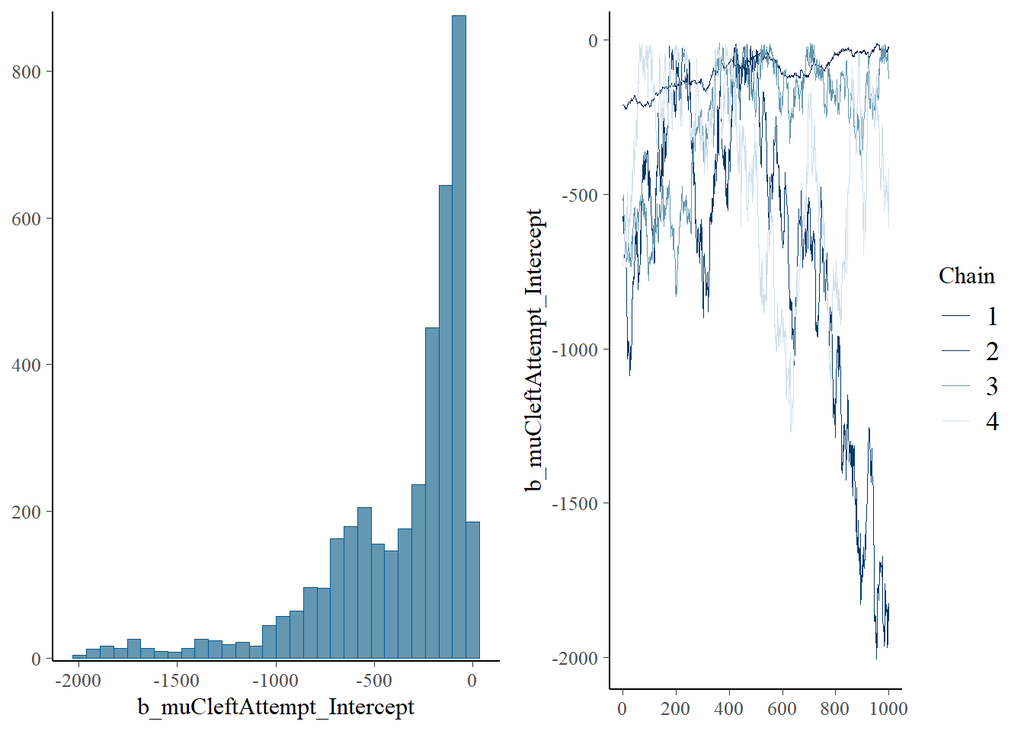

```r
#way too many plot
plot(brm_model_full_wo_priors, variable = "b_muCleftAttempt_Intercept")
```

We end up with convergence problems, and Rhat > 1.05, which most likely come from the quasi-complete separation of our data that flat priors can’t handle (“flat” pour la classe “b”). Adding priors will make our results more reliable as well as drastically reduce computing time.

```r
get_prior(brm_model_full_wo_priors)[1:10,]
```

#### Testing with the full model and specified priors

Setting the priors for coefficients to $Normal(0,10)$ on the log-odds scale means we center the parameters around the fact that the parameter as no effect, but with a good amount of uncertainty (still not as much as a flat prior).

##### Why this prior ?

The statistical intuition:

Change between something that has a 99% chance of happening or a 99.9% chance of happening are not that big on the log-odds scale. Here x2 is the reference level.

```r
n_x1 <- 1
N <- 10

p1 <- n_x1/N

(odds_p1 <- p1/(1-p1)) #odds of x1
```

```
[1] 0.1111111
```

```r
n_x2 <- 9
p2 <- n_x2/N

(odds_p2 <- p2/(1-p2)) #odds of x2
```

```
[1] 9
```

```r
log(odds_p1/odds_p2) #log odds ratio
```

```
[1] -4.394449
```

```r
n_x1 <- 1
N <- 100

p1 <- n_x1/N

(odds_p1 <- p1/(1-p1)) #odds of x1
```

```
[1] 0.01010101
```

```r
n_x2 <- 99
p2 <- n_x2/N

(odds_p2 <- p2/(1-p2)) #odds of x2
```

```
[1] 99
```

```r
log(odds_p1/odds_p2) #log odds ratio
```

```
[1] -9.19024
```

```r
n_x1 <- 1
N <- 1000

p1 <- n_x1/N

(odds_p1 <- p1/(1-p1)) #odds of x1
```

```
[1] 0.001001001
```

```r
n_x2 <- 999
p2 <- n_x2/N

(odds_p2 <- p2/(1-p2)) #odds of x2
```

```
[1] 999
```

```r
log(odds_p1/odds_p2) #log odds ratio
```

```
[1] -13.81351
```

In our case, $N \approx 200$. So we need a prior that simulate enough values from the range of -15 to 15 to be safe, but there is less need for anything beyond this range.

```r
rm(n_x1, n_x2, p1, p2, odds_p1, odds_p2, N)
```

##### A Cauchy prior

I found out one recommendation for logistic regression (that should apply for categorical data), was to use the Cauchy distribution with a mean of 0 and scale 2.5 with scaled numerical dependant variable (of which we don’t have any) Gelman et al. (2008). As you can see below, it’s not that far of the normal distribution we are going to use, it just has more weight around 0 while still leaving room for more extreme values.

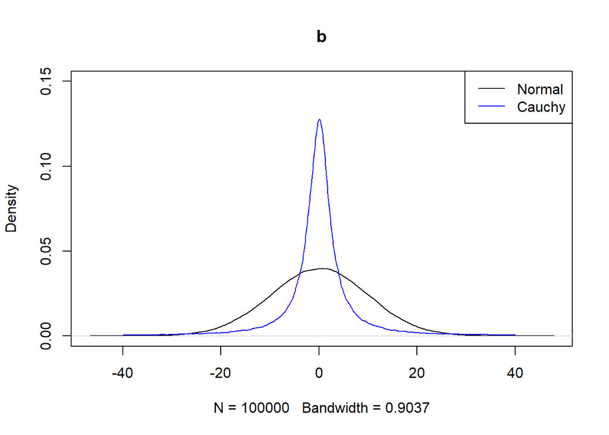

```r
plot(density(rnorm(n = 100000, mean = 0, sd = 10)), main = "b", ylim = c(0, 0.15))
lines(density(rcauchy(n = 100000, location = 0, scale = 2.5),
             from = -40, to = 40), col = "blue") #add a legend
legend(x = "topright",
       legend = c("Normal", "Cauchy"),
                  col = c("black", "blue"),
       lty = 1)
```

Unfortunately the Cauchy prior is not implemented in the *brms* package, but hopefully the rest of the WAMBS check-list will convince you that the normal prior used is good enough.

##### Running the full model

Let’s add the normal prior to our model. Right now the default priors look like this:

```r
priors <- get_prior(model_formula,
                    data = dt,
                    family = categorical())

priors[1:25,]
```

|  | prior | class | coef | group | resp | dpar | nlpar | lb | ub | source |
| --- | --- | --- | --- | --- | --- | --- | --- | --- | --- | --- |
| 1 | lkj(1) | cor |  |  |  |  |  |  |  | default |
| 2 |  | cor |  | Item |  |  |  |  |  | default |
| 3 |  | cor |  | Participant |  |  |  |  |  | default |
| 4 |  | b |  |  |  | muCleftAttempt |  |  |  | default |
| 5 |  | b | Age_group3yDo |  |  | muCleftAttempt |  |  |  | default |
| 6 |  | b | Age_group3yDo:ConditionAdjunct |  |  | muCleftAttempt |  |  |  | default |
| 7 |  | b | Age_group3yDo:ConditionDirect_object |  |  | muCleftAttempt |  |  |  | default |
| 8 |  | b | Age_group3yDo:ConditionIndirect_object |  |  | muCleftAttempt |  |  |  | default |
| 9 |  | b | Age_group4yDo |  |  | muCleftAttempt |  |  |  | default |
| 10 |  | b | Age_group4yDo:ConditionAdjunct |  |  | muCleftAttempt |  |  |  | default |

[output cut: 15 more lines]

Adding the normal prior:

```r
#will be put on all "b" type priors, population level effects (and all corresponding dpar, distributionnal parameters),
#and also all coef, coefficient within the parameter class (i.e. the independant/predictor variables)
#this last part isn't shown in the "priors" table but is applied in the model (see below)
priors$prior[priors$class =="b" & priors$coef == ""] <- "normal(0,10)"

priors[1:25,]
```

|  | prior | class | coef | group | resp | dpar | nlpar | lb | ub | source |
| --- | --- | --- | --- | --- | --- | --- | --- | --- | --- | --- |
| 1 | lkj(1) | cor |  |  |  |  |  |  |  | default |
| 2 |  | cor |  | Item |  |  |  |  |  | default |
| 3 |  | cor |  | Participant |  |  |  |  |  | default |
| 4 | normal(0,10) | b |  |  |  | muCleftAttempt |  |  |  | default |
| 5 |  | b | Age_group3yDo |  |  | muCleftAttempt |  |  |  | default |
| 6 |  | b | Age_group3yDo:ConditionAdjunct |  |  | muCleftAttempt |  |  |  | default |
| 7 |  | b | Age_group3yDo:ConditionDirect_object |  |  | muCleftAttempt |  |  |  | default |
| 8 |  | b | Age_group3yDo:ConditionIndirect_object |  |  | muCleftAttempt |  |  |  | default |
| 9 |  | b | Age_group4yDo |  |  | muCleftAttempt |  |  |  | default |
| 10 |  | b | Age_group4yDo:ConditionAdjunct |  |  | muCleftAttempt |  |  |  | default |

[output cut: 15 more lines]

Let’s do a quick check on the prior. This model is really easy to run as it only checks the prior distribution (no likelihood or posterior computed here) !

```r
#doesn't take long
job::job({
  brm(model_formula,
      data = dt,
      family = categorical(),
      prior = priors,
      cores = 4,
      sample_prior = 'only',
      file = "brm_model_full_priors_only")

})
```

```r
brm_model_full_priors_only <- readRDS(file = "brm_model_full_priors_only.rds")
```

The following line allows you to easily check what priors you have effectively attributed to the model without going through stancode (`make_stancode()`). Unfortunately, we cannot do that with the model without priors here, as the model is complaining about no prior defined (which I think has something to do with the default flat priors that would show an infinite range of possible values). Here we want $y_{rep}$ to show a large variation around $y$.

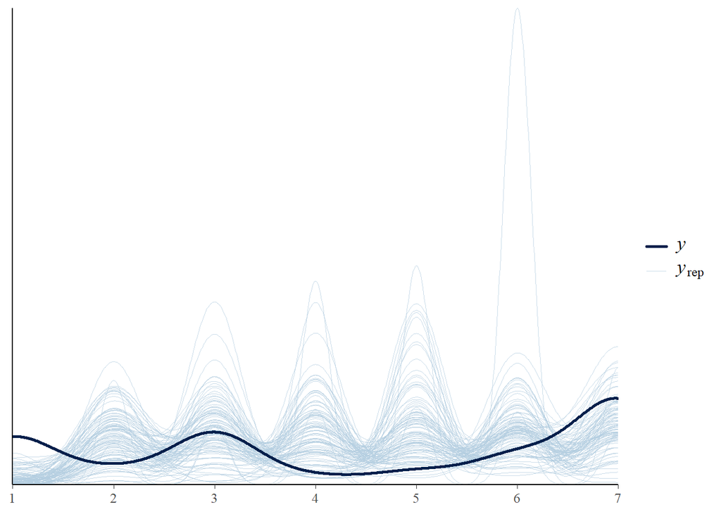

```r
#Compare the empirical distribution of the data y to the distributions of simulated/replicated data yrep from the posterior predictive distribution.
#default to density overlay
pp_check(brm_model_full_priors_only, ndraws=100)
```

Do a quick check to see if the model works with default settings and specified priors.

```r
#don't run this unless necessary (takes time)

#this takes a while to run (45min)
#use the job package to make it run in the background
job::job({
  brm(
    model_formula,
    data = dt,
    family = categorical(),
    prior = priors,
    cores = 4,
    file = "brm_model_full_check")

})
```

Posterior predictive check. Here we want $y_{rep}$ to have a small variation around $y$ :

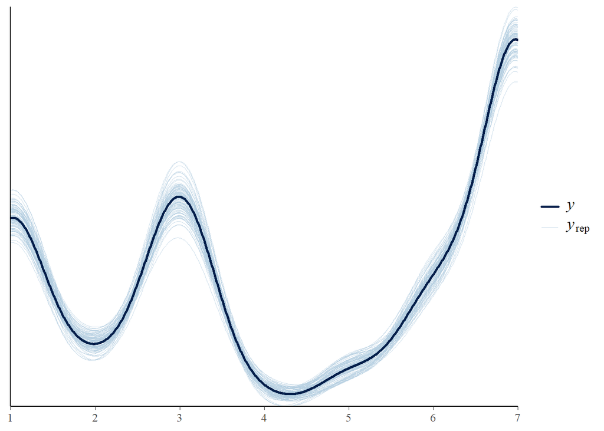

```r
brm_model_full_check <- readRDS("brm_model_full_check.rds")

pp_check(brm_model_full_check, ndraws=100)
```

This model seems to work, so let’s run it a little longer to makes sure the chains are mixing well.

```r
#don't run this unless necessary (takes time)

#this takes a while to run (20 mins ?)
#use the job package to make it run in the background
job::job({
  brm(
    model_formula,
    data = dt,
    family = categorical(),
    prior = priors,
    iter = 4000,
    warmup = 1000,
    cores = 4,
    control = list(adapt_delta = 0.95),
    seed = 24102024,
    file = "brm_model_full"
)})
```

```r
brm_model_full <- readRDS("brm_model_full.rds")
```

```r
#if you want to see the actual Stan code
stancode(brm_model_full)
```

Posterior predictive check:

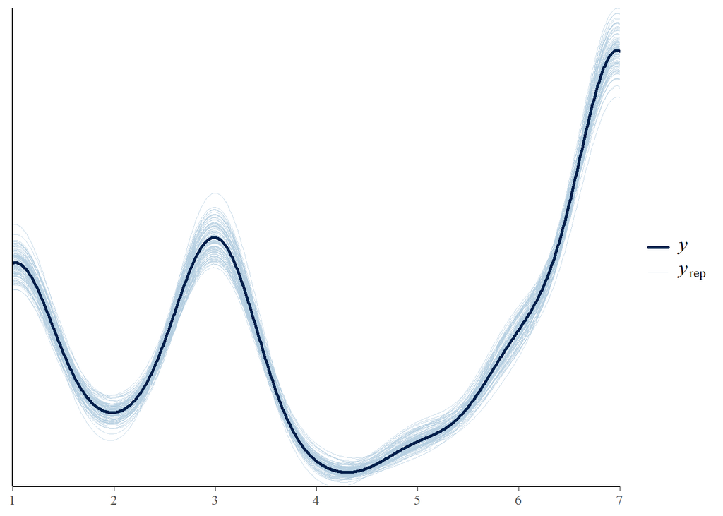

```r
pp_check(brm_model_full,  ndraws=100)
```

### Results of Bayesian analysis

```r
#too big alone
sum_brm_model_full <- summary(brm_model_full)
posterior_summary <- sum_brm_model_full$fixed
```

The results below are on the log-odds scale:

```r
posterior_summary[1:10,] # out of 96
```

|  | Estimate | Est.Error | l-95% CI | u-95% CI | Rhat | Bulk_ESS | Tail_ESS |
| --- | --- | --- | --- | --- | --- | --- | --- |
| muCleftAttempt_Intercept | -8.3127845 | 2.5286995 | -13.9683566 | -4.36490947 | 1.000748 | 4321.000 | 4546.201 |
| muConstituant_Intercept | -0.5442994 | 0.1922498 | -0.9267292 | -0.17297459 | 1.000368 | 6635.573 | 9044.747 |
| muIdentSentence_Intercept | -3.0354342 | 0.5277231 | -4.1631190 | -2.08328133 | 1.000268 | 6733.149 | 7570.452 |
| muOther_Intercept | -8.8280364 | 2.6449117 | -14.7082674 | -4.62501666 | 1.000427 | 3562.580 | 4173.309 |
| muReducedCleft_Intercept | -2.5398911 | 0.4092871 | -3.4128292 | -1.81969841 | 1.000130 | 4787.169 | 5748.469 |
| muSentence_Intercept | -0.2588771 | 0.1775893 | -0.6144582 | 0.08909836 | 1.000128 | 6086.116 | 8663.693 |
| muCleftAttempt_Age_group3yDo | -2.9975153 | 4.5422418 | -13.0571559 | 4.80511326 | 1.000298 | 7921.329 | 8054.576 |
| muCleftAttempt_Age_group4yDo | 6.1778623 | 2.5569540 | 2.1600389 | 11.85782507 | 1.000856 | 4360.020 | 4577.485 |
| muCleftAttempt_Age_group5yDo | 7.1756647 | 2.5387347 | 3.2128357 | 12.86351689 | 1.000767 | 4388.296 | 4303.276 |
| muCleftAttempt_ConditionAdjunct | -2.4119240 | 4.1433909 | -11.3272241 | 4.89363076 | 1.000439 | 6723.590 | 7243.010 |

The fact that the category **Cleft** is not present in the summary above is due to the way a categorical family model is parametrized in *brms*, with the first factor of **Answer_Type** fixed to 0 (see *Notation* (n.d.)). It is in fact our reference, just like we can see among our dependant variable that there is no **Adults** for **Group_Age** and no **Subject** for **Condition**, which are also reference levels.

We are going to focus on whether the Credible Interval contains 0 or not (made using the Equivalent tailed interval). We will also put the Probability of Direction (PD), as well as its equivalent p-value.

“Thus, a two-sided p-value of respectively .1, .05, .01 and .001 would correspond approximately to a pd of 95%, 97.5%, 99.5% and 99.95%” from the reporting guidelines Makowski et al. (2019). We will use these interpretation helper here.

We won’t be using the ROPE here. Using the ROPE for something other that numerical variable would require setting up a correct ROPE CI (what’s more, collinearity invalidates ROPE as the probabilities are conditional on independence and cannot be used for hypothesis testing based on univariate marginals).

```r
get_result_table <- function(brm_model){
  sum_brm_model_full <- summary(brm_model)
  posterior_summary <- sum_brm_model_full$fixed

  tmp_result_table <- posterior_summary[,c("Estimate", "l-95% CI", "u-95% CI")]

  tmp_result_table <- tmp_result_table %>%
    mutate(`Position CI compared to 0` = case_when(
      `l-95% CI` < 0 & `u-95% CI` > 0 ~ "contains 0",
      `l-95% CI` > 0 ~ "above 0",
      `u-95% CI` < 0 ~ "below 0"))

  tmp_result_table[,c("Estimate",
                      "l-95% CI",
                      "u-95% CI")] <- round(tmp_result_table[,c("Estimate",
                                                                "l-95% CI",
                                                                "u-95% CI")], 2)
  tmp_result_table$PD <- bayestestR::p_direction(brm_model, as_p = FALSE)$pd
  tmp_result_table$`Eq. p-value` <- bayestestR::pd_to_p(tmp_result_table$PD)
  tmp_result_table$PD <- paste0(round(tmp_result_table$PD*100,2), "%")
  tmp_result_table$`Eq. p-value` <-insight::format_p(tmp_result_table$`Eq. p-value`)

  return(tmp_result_table)
}

results_brm_model_full <- get_result_table(brm_model_full)
```

```r
results_brm_model_full[1:10,]
```

|  | Estimate | l-95% CI | u-95% CI | Position CI compared to 0 | PD | Eq. p-value |
| --- | --- | --- | --- | --- | --- | --- |
| muCleftAttempt_Intercept | -8.31 | -13.97 | -4.36 | below 0 | 100% | p < .001 |
| muConstituant_Intercept | -0.54 | -0.93 | -0.17 | below 0 | 99.78% | p = 0.004 |
| muIdentSentence_Intercept | -3.04 | -4.16 | -2.08 | below 0 | 100% | p < .001 |
| muOther_Intercept | -8.83 | -14.71 | -4.63 | below 0 | 100% | p < .001 |
| muReducedCleft_Intercept | -2.54 | -3.41 | -1.82 | below 0 | 100% | p < .001 |
| muSentence_Intercept | -0.26 | -0.61 | 0.09 | contains 0 | 92.79% | p = 0.144 |
| muCleftAttempt_Age_group3yDo | -3.00 | -13.06 | 4.81 | contains 0 | 73.31% | p = 0.534 |
| muCleftAttempt_Age_group4yDo | 6.18 | 2.16 | 11.86 | above 0 | 100% | p < .001 |
| muCleftAttempt_Age_group5yDo | 7.18 | 3.21 | 12.86 | above 0 | 100% | p < .001 |
| muCleftAttempt_ConditionAdjunct | -2.41 | -11.33 | 4.89 | contains 0 | 70.13% | p = 0.597 |

```r
write.csv(results_brm_model_full, file = "results.csv")
```

#### Answering specific questions

Example question:

Does Cleft production in the subject condition significantly increase across age group ?

Small precision : “across the entire population of participants” is implied here, suggesting that we are looking for a marginal effect (prediction is averaged over the random effects) rather than a conditional effect (which would vary by participant and item).

```r
# Create dataframe needed to calculate the expected posterior predictive distribution
newdata <- expand.grid(
  Age_group = c("3 y/o", "4 y/o", "5 y/o", "Adults"), #the 4 age groups
  Condition = "Subject", # only for the condition SUBJECT
  Item = NA,            # Les effets aléatoires peuvent être moyennés
  Participant = NA
)
```

Expectation of the posterior predictive distribution, aka the conditional expectation, $E(y_{new}|x_{new}, y_{obs})$ to the data.

```r
#epred_draws is basically a neater version of the brms package posterior_epred
mean_Cleft_d_ages <- brm_model_full %>%
  tidybayes::epred_draws(newdata = newdata,
                         re_formula = NA)%>% # put re_formula = NULL for conditional mean
  filter(.category == "Cleft")

compare_mean_Cleft_d_ages <- mean_Cleft_d_ages %>%
  tidybayes::compare_levels(variable = .epred,
                            by = Age_group,
                            comparison = "ordered")

compare_mean_Cleft_d_ages %>%
  ggdist::median_qi()
```

| Age_group | Condition | Item | Participant | .category | .epred | .lower | .upper | .width | .point | .interval |
| --- | --- | --- | --- | --- | --- | --- | --- | --- | --- | --- |
| 4 y/o - 3 y/o | Subject | NA | NA | Cleft | -0.15331816 | -0.25180776 | -0.05224322 | 0.95 | median | qi |
| 5 y/o - 4 y/o | Subject | NA | NA | Cleft | -0.01994514 | -0.10756290 | 0.06748937 | 0.95 | median | qi |
| Adults - 5 y/o | Subject | NA | NA | Cleft | 0.16516610 | 0.07459622 | 0.25408611 | 0.95 | median | qi |

Plotting

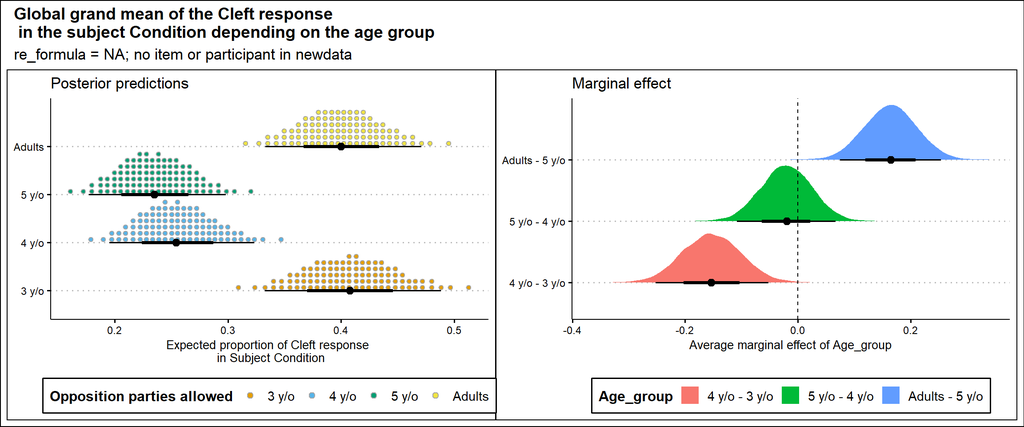

```r
p1 <- mean_Cleft_d_ages %>%
  ggplot(aes(x = .epred, y = Age_group, fill = Age_group)) +
  ggdist::stat_dotsinterval(quantiles = 100) +
  ggokabeito::scale_fill_okabe_ito() +
  labs(x = "Expected proportion of Cleft response \n in Subject Condition", y = NULL,
       fill = "Opposition parties allowed",
       subtitle = "Posterior predictions") +
  ggthemes::theme_clean() +
  theme(legend.position = "bottom")


p2 <- compare_mean_Cleft_d_ages %>%
  ggplot(aes(x = .epred, y = Age_group, fill = Age_group)) +
  ggdist::stat_halfeye() +
  geom_vline(xintercept = 0, linetype = "dashed") +
  labs(x = "Average marginal effect of Age_group", y = NULL,
       subtitle = "Marginal effect") +
  ggthemes::theme_clean() +
  theme(legend.position = "bottom")

# Combined plot
(p1 | p2) +
  plot_annotation(title = "Global grand mean of the Cleft response \n in the subject Condition depending on the age group",
                  subtitle = "re_formula = NA; no item or participant in newdata",
                  theme = ggthemes::theme_clean())
```

```r
save.image(file = "analysis.RData")
```

#### A few graphics to better understand the data overall

Marginal with regards to the the Age group and the Condition respectively

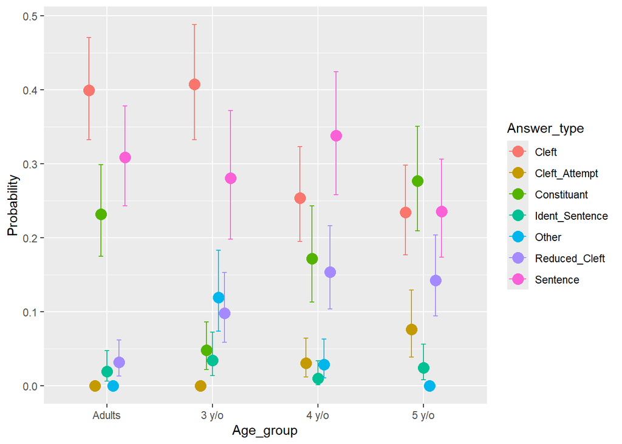

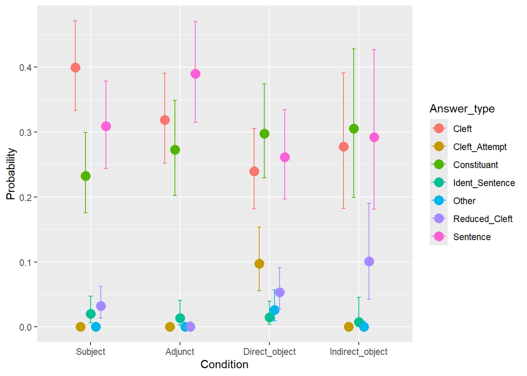

```r
conditional_effects(brm_model_full, categorical = T, ask = FALSE)
```

Fully conditional graph:

```r
conditions <- make_conditions(brm_model_full, "Age_group")

c_eff <- conditional_effects(brm_model_full, "Condition", conditions = conditions,
                    categorical = T,
                    ncol = 2) #you can make a plot with just conditional_effect


c_eff <- as.data.frame(c_eff$`Condition:cats__`)

c_eff$Answer_type <- c_eff$cats__
```

A slightly better plot:

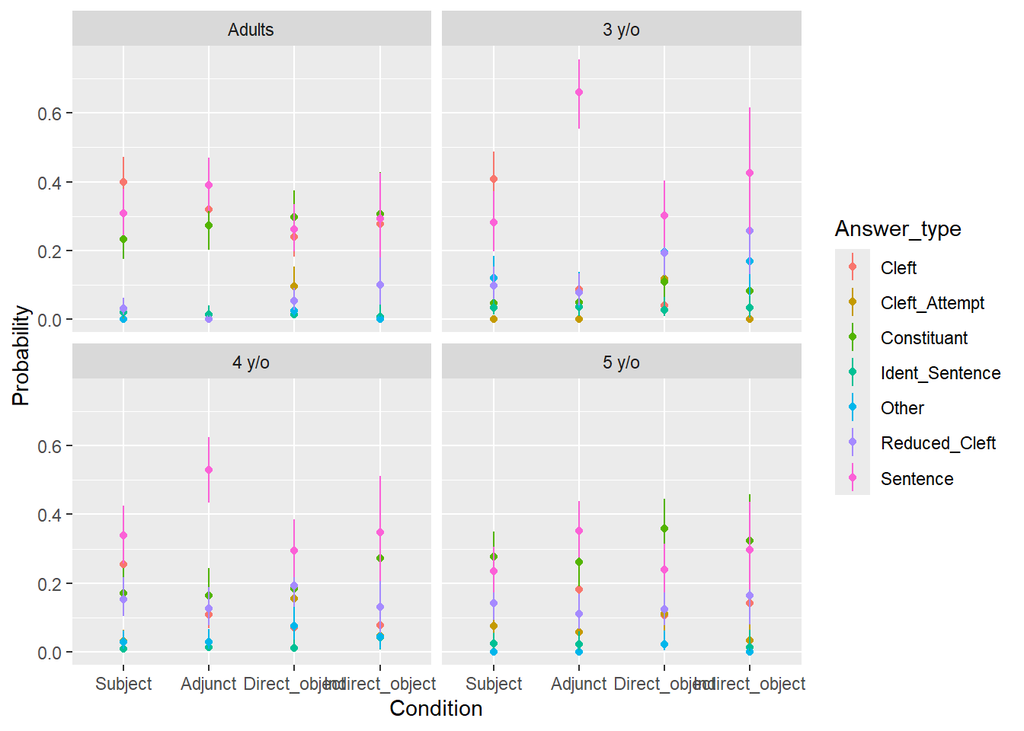

```r
#creating plot
ggplot(c_eff,aes(x=Condition,y=estimate__, group=Answer_type,
                 fill = Answer_type, color = Answer_type))+
  geom_point()+
  geom_linerange(aes(ymin=lower__, ymax=upper__))+
  facet_wrap(vars(Age_group), nrow = 2)+
  #geom_line(size=1, position=position_dodge(0.05), aes(color=cats__, linetype=cats__))+
  labs(y="Probability",x="Condition")
```

### WAMBS v2

To verify that the analysis was performed correctly, we can do the check-up presented by Schoot et al. (2021) which has a version in R “WAMBS Checklist in r (Using Brms)” (n.d.).

#### 1. Do you understand the priors?

```r
#function to only show unique unique_prior_per_class
# otherwise the table from get priors has 171 lines...
show_unique_prior_per_class <- function(brm_model){
  prior_used <- get_prior(brm_model)
  unique_prior_used <- prior_used[!duplicated(as.data.frame(prior_used[,c("prior", "class")])),]
  return(unique_prior_used)
}

show_unique_prior_per_class(brm_model_full)
```

|  | prior | class | coef | group | resp | dpar | nlpar | lb | ub | source |
| --- | --- | --- | --- | --- | --- | --- | --- | --- | --- | --- |
| 1 | normal(0,10) | b |  |  |  | muCleftAttempt |  |  |  | default |
| 2 |  | b | Age_group3yDo |  |  | muCleftAttempt |  |  |  | default |
| 97 | student_t(3, 0, 2.5) | Intercept |  |  |  | muCleftAttempt |  |  |  | default |
| 103 | lkj_corr_cholesky(1) | L |  |  |  |  |  |  |  | default |
| 104 |  | L |  | Item |  |  |  |  |  | default |
| 106 | student_t(3, 0, 2.5) | sd |  |  |  | muCleftAttempt |  | 0 |  | default |
| 112 |  | sd |  | Item |  | muCleftAttempt |  |  |  | default |

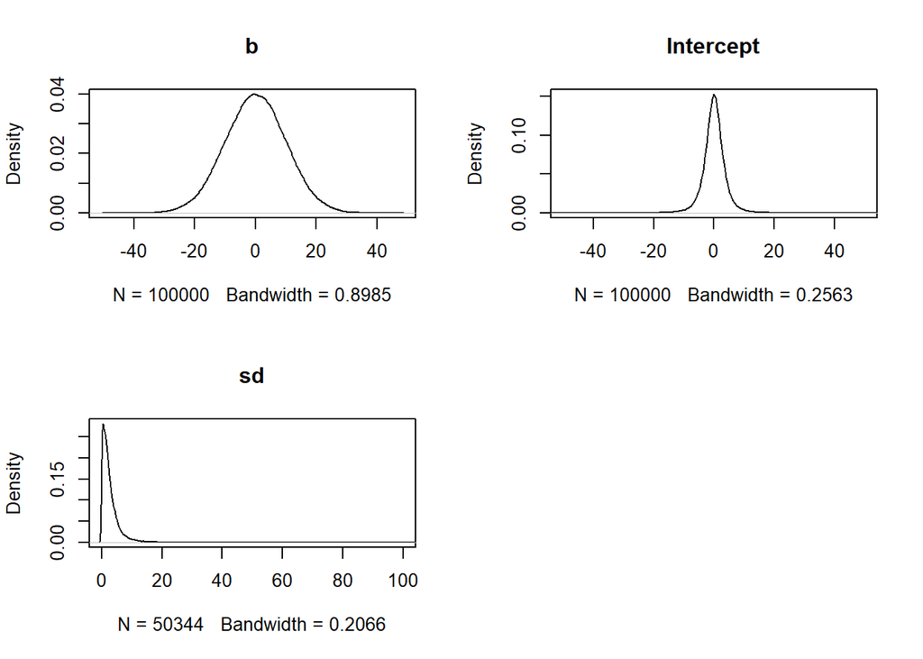

```r
par(mfrow = c(2,2))
# the rnorm function uses the standard devation instead of variance, that is why we use the sqrt
plot(density(rnorm(n = 100000, mean = 0, sd = 10)), main = "b")

for_shift_scale_T_dist <- stevemisc::rst(n = 100000, df = 3, mu = 0, sigma = 2.5)
for_shift_scale_T_dist_pos <- for_shift_scale_T_dist[for_shift_scale_T_dist>0]


plot(density(for_shift_scale_T_dist), main = "Intercept", xlim = c(-50, 50))
plot(density(for_shift_scale_T_dist_pos), main = "sd", xlim = c(0, 100))

#lacks the correlation but i don't have a good way of representing it
```

#### 2. Does the trace-plot exhibit convergence?

There are too much parameters to converge to check them out visually. We can check them using convergence diagnostics.

The Gelman-Rubin Diagnostic shows the PSRF values (using the within and between chain variability). You should look at the Upper CI/Upper limit, which are all should be close to 1. If they aren’t close to 1, you should use more iterations. Note: The Gelman and Rubin diagnostic is also automatically given in the summary of *brms* under the column Rhat.

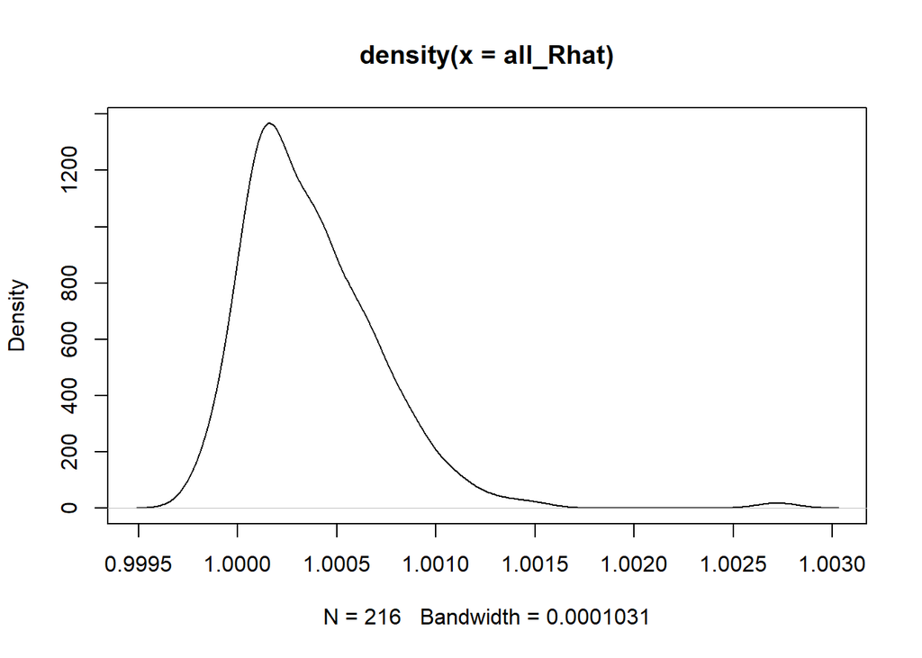

```r
all_Rhat <- c(sum_brm_model_full$fixed$Rhat,
               sum_brm_model_full$random$Item$Rhat,
               sum_brm_model_full$random$Participant$Rhat)
plot(density(all_Rhat))
```

There is question regarding the Rhat as a measure of convergeance “Rank-Normalization, Folding, and Localization: An Improved r for Assessing Convergence of MCMC (Online Appendix)” (n.d.).

Another way to test for convergence is the Monte Carlo standard error :

“One way to compute Monte Carlo standard errors is with the method of *batch means*. The idea here is we divide our long MCMC sampler chain into equal size segments and compute our summary statistic on each segment. If the segments are of the proper size, we can think of them as “independent replicates”, even though individual samples of the MCMC sampler will not be independent of each other in general. From these replicates, we compute an estimate of variability from the given chain. […] It’s worth nothing that the Monte Carlo standard error is a quantity with units attached to it. Therefore, determining when the standard error is “small enough” will require a certain understanding of the context in which the problem is being addressed.” (Peng, n.d.)

Implementation from the package BayestestR comes from J. Kruschke (2014)

```r
bayestestR::mcse(brm_model_full)[1:10,]
```

|  | Parameter | MCSE |
| --- | --- | --- |
| 1 | b_muCleftAttempt_Intercept | 0.040854617 |
| 2 | b_muConstituant_Intercept | 0.002369664 |
| 3 | b_muIdentSentence_Intercept | 0.006544090 |
| 4 | b_muOther_Intercept | 0.046323608 |
| 5 | b_muReducedCleft_Intercept | 0.006025447 |
| 6 | b_muSentence_Intercept | 0.002281478 |
| 7 | b_muCleftAttempt_Age_group3yDo | 0.051881697 |
| 8 | b_muCleftAttempt_Age_group4yDo | 0.041097115 |
| 9 | b_muCleftAttempt_Age_group5yDo | 0.040777955 |
| 10 | b_muCleftAttempt_ConditionAdjunct | 0.050947609 |

Graphically:

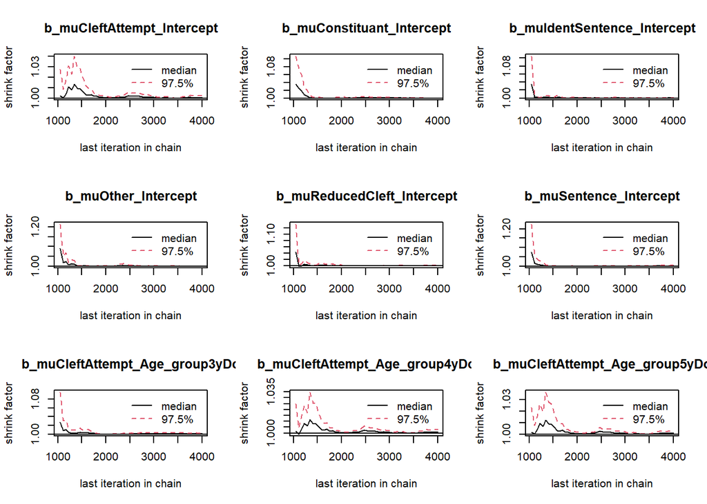

```r
modelposterior <- as.mcmc(brm_model_full)
#coda::gelman.diag(modelposterior) equivalant to RHat

#only the first 96 are "b" parameters the rest are for the random part of the model
coda::gelman.plot(modelposterior[,1:9])
```

The Geweke Diagnostic shows the z-scores for a test of equality of means between the first and last parts of each chain, which should be <1.96. A separate statistic is calculated for each variable in each chain. In this way it check whether a chain has stabilized. If this is not the case, you should increase the number of iterations. In the plots you should check how often values exceed the boundary lines of the z-scores. Scores above 1.96 or below -1.96 mean that the two portions of the chain significantly differ and full chain convergence was not obtained.

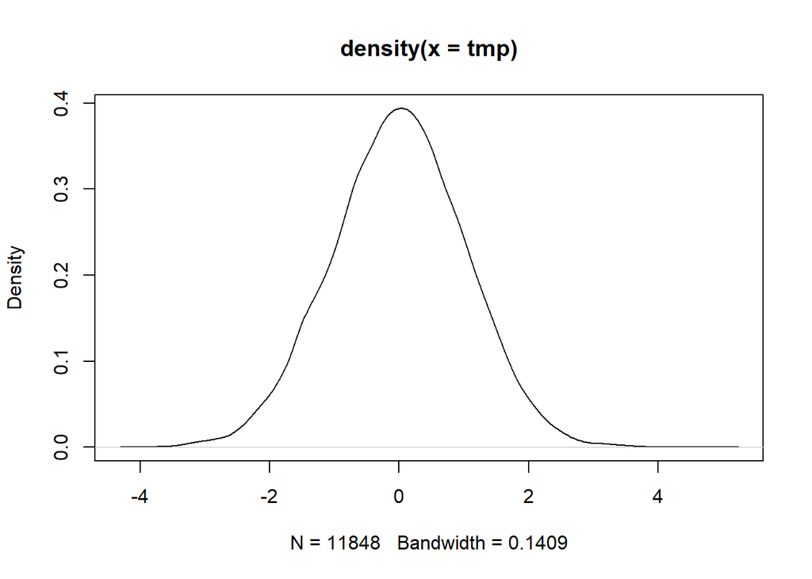

```r
tmp <- unlist(coda::geweke.diag(modelposterior))

plot(density(tmp))
```

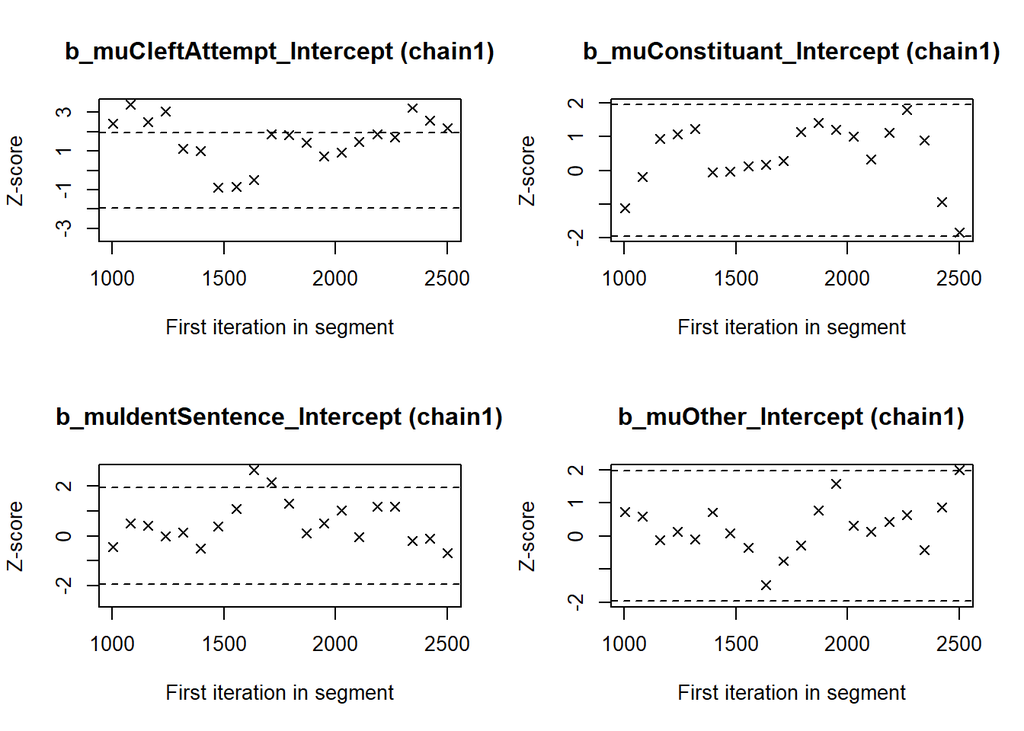

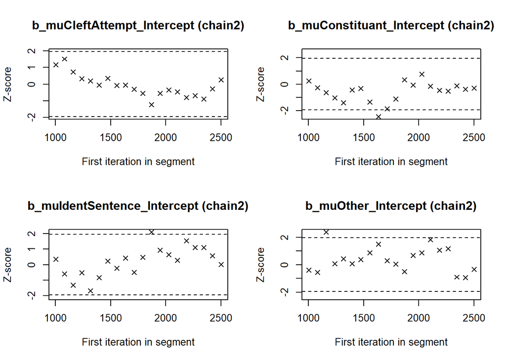

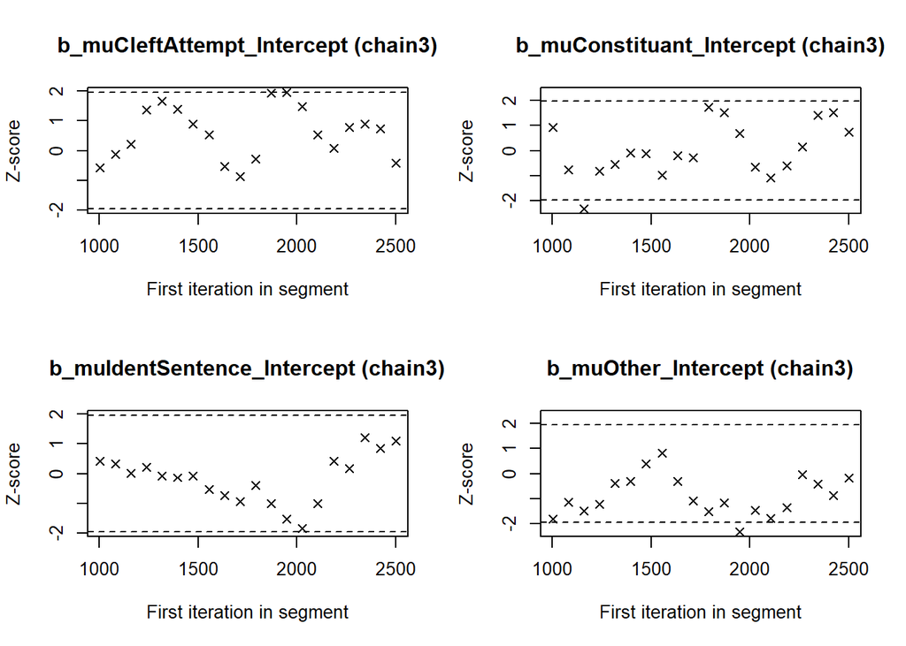

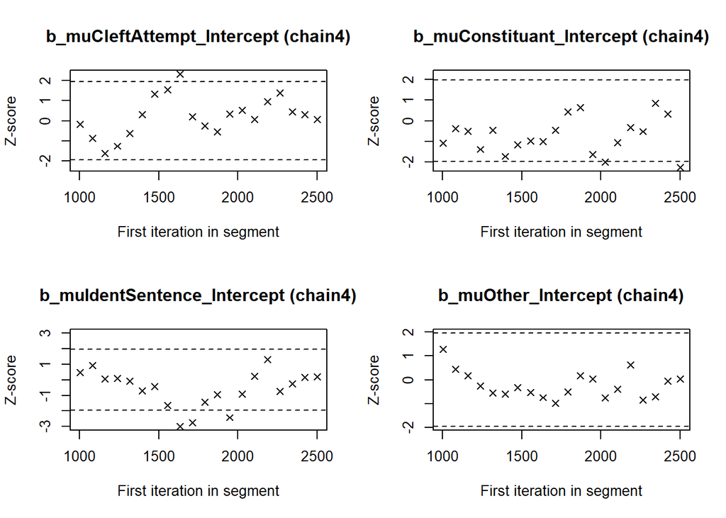

```r
#coda::geweke.diag(modelposterior) ##too much
coda::geweke.plot(modelposterior[, 1:4])
```

```r
bayestestR::diagnostic_posterior(brm_model_full)[1:10,]
```

|  | Parameter | Rhat | ESS | MCSE |
| --- | --- | --- | --- | --- |
| 1 | b_muCleftAttempt_Age_group3yDo | 1.0002895 | 7664.770 | 0.05188170 |
| 2 | b_muCleftAttempt_Age_group3yDo:ConditionAdjunct | 0.9999953 | 14884.682 | 0.06302730 |
| 3 | b_muCleftAttempt_Age_group3yDo:ConditionDirect_object | 1.0003901 | 7724.187 | 0.05195766 |
| 4 | b_muCleftAttempt_Age_group3yDo:ConditionIndirect_object | 0.9999884 | 16270.105 | 0.06784467 |
| 5 | b_muCleftAttempt_Age_group4yDo | 1.0009406 | 3871.291 | 0.04109712 |
| 6 | b_muCleftAttempt_Age_group4yDo:ConditionAdjunct | 0.9999630 | 6708.381 | 0.05089742 |
| 7 | b_muCleftAttempt_Age_group4yDo:ConditionDirect_object | 1.0010383 | 3919.107 | 0.04134314 |
| 8 | b_muCleftAttempt_Age_group4yDo:ConditionIndirect_object | 0.9999974 | 6328.613 | 0.05582772 |
| 9 | b_muCleftAttempt_Age_group5yDo | 1.0009355 | 3875.706 | 0.04077795 |
| 10 | b_muCleftAttempt_Age_group5yDo:ConditionAdjunct | 0.9999976 | 6590.915 | 0.05117089 |

If you need to diagnostic all the draws…

```r
bayestestR::diagnostic_draws(brm_model_full)
```

#### 3. Does convergence remain after doubling the number of iterations?

As is recommended in the WAMBS checklist, we double the amount of iterations to check for local convergence.

```r
#don't run this unless necessary (takes time)

#this takes a while to run (20 mins ?)
#use the job package to make it run in the background
job::job({
  brm(
    model_formula,
    data = dt,
    family = categorical(),
    prior = priors,
    iter = 8000,
    warmup = 1000,
    cores = 4,
    control = list(adapt_delta = 0.95),
    file = "brm_model_full_double_iter"
)})
```

“You should again have a look at the above-mentioned convergence statistics, but we can also compute the relative bias to inspect if doubling the number of iterations influences the posterior parameter estimates. In order to preserve clarity we just calculate the bias of the two regression coefficients.

You should combine the relative bias in combination with substantive knowledge about the metric of the parameter of interest to determine when levels of relative deviation are negligible or problematic. For example, with a regression coefficient of 0.001, a 5% relative deviation level might not be substantively relevant. However, with an intercept parameter of 50, a 10% relative deviation level might be quite meaningful. The specific level of relative deviation should be interpreted in the substantive context of the model. Some examples of interpretations are:

```
if relative deviation is < |5|%, then do not worry;
if relative deviation > |5|%, then rerun with 4x nr of iterations."
```

“WAMBS Checklist in r (Using Brms)” (n.d.)

I don’t like to do the relative bias on the estimates because some of our estimates are really close to 0. And when the estimates is close to 0, the bias will be huge but this won’t have any impact on our interpretation of the results. In fact, all relative bias measures will show huge differences when the estimates are close to 0… .

Example below for the percent error measure presented by Rens van de Schoot:

```r
100*((4 - 4.1)/4)
```

```
[1] -2.5
```

```r
100*((1 - 1.1)/1)
```

```
[1] -10
```

```r
100*((0.1 - 0.2)/0.1)
```

```
[1] -100
```

We could look at the relative difference of the PD, since it is bounded between 50 and 100.

```r
100*((50 - 51)/50)
```

```
[1] -2
```

```r
100*((98 - 99)/98)
```

```
[1] -1.020408
```

```r
100*((98 - 50)/98)
```

```
[1] 48.97959
```

```r
brm_model_full_double_iter <- readRDS("brm_model_full_double_iter.rds")

results_brm_model_full_double_iter <- get_result_table(brm_model_full_double_iter)
```

```r
#function to get the numerical PD from our result table
get_num_PD <- function(percent_PD){
  num_pd <- as.numeric(stringr::str_extract(percent_PD, "\\d+\\.*\\d*"))
  return(num_pd)
}

#function to calculate the relative bias
get_relative_bias_PD <- function(result_model_1, result_model_2){
  PD1 <- get_num_PD(result_model_1$PD)
  PD2 <- get_num_PD(result_model_2$PD)
  rel_bias_PD <- 100*((PD1-PD2)/PD1)
  return(rel_bias_PD)
}

sort(get_relative_bias_PD(results_brm_model_full,
                          results_brm_model_full_double_iter))
```

```
 [1] -1.81532554 -1.38635534 -1.23219099 -0.95653633 -0.88439672 -0.81568403
 [7] -0.75026795 -0.61959889 -0.49378200 -0.44813641 -0.41351775 -0.33634887
[13] -0.31014024 -0.30788177 -0.26113070 -0.23189197 -0.22042616 -0.21189647
[19] -0.15283329 -0.10679197 -0.07028818 -0.04161465 -0.03007820 -0.02065262
[25] -0.02015520 -0.02012477 -0.01011531 -0.01002205 -0.01000100  0.00000000
[31]  0.00000000  0.00000000  0.00000000  0.00000000  0.00000000  0.00000000
[37]  0.00000000  0.00000000  0.00000000  0.00000000  0.00000000  0.00000000
[43]  0.00000000  0.00000000  0.00000000  0.00000000  0.00000000  0.00000000
[49]  0.00000000  0.01000000  0.01000000  0.01000000  0.01000300  0.01410835
[55]  0.01431639  0.02000600  0.02002403  0.03011746  0.04053096  0.04345937
[61]  0.09941593  0.11571842  0.13608528  0.15317544  0.18146468  0.18608498
[67]  0.20161290  0.20178420  0.22744503  0.27034334  0.28967254  0.30985334
[73]  0.32352327  0.32807054  0.33898305  0.35037098  0.37719582  0.38680782
[79]  0.39303026  0.42447307  0.42499426  0.44194456  0.46790642  0.47107015
[85]  0.47477745  0.50067800  0.51893408  0.57206642  0.63067608  0.72958888
[91]  0.77538769  0.83546842  0.95177665  1.16818931  1.45027624  2.19097449
```

Alternatively, we could also just look at differences between both models estimates and their CrI.

```r
results_brm_model_full[1:10,1:3] - results_brm_model_full_double_iter[1:10,1:3]
```

|  | Estimate | l-95% CI | u-95% CI |
| --- | --- | --- | --- |
| muCleftAttempt_Intercept | 0.04 | 0.02 | 0.01 |
| muConstituant_Intercept | 0.00 | -0.01 | -0.01 |
| muIdentSentence_Intercept | -0.01 | 0.02 | 0.00 |
| muOther_Intercept | -0.01 | -0.09 | -0.06 |
| muReducedCleft_Intercept | 0.00 | 0.01 | -0.03 |
| muSentence_Intercept | -0.01 | 0.00 | 0.00 |
| muCleftAttempt_Age_group3yDo | 0.01 | -0.01 | 0.01 |
| muCleftAttempt_Age_group4yDo | -0.02 | 0.02 | -0.02 |
| muCleftAttempt_Age_group5yDo | -0.03 | 0.03 | -0.03 |
| muCleftAttempt_ConditionAdjunct | -0.07 | -0.16 | -0.06 |

Looking at the actual estimates:

```r
cbind.data.frame(results_brm_model_full, results_brm_model_full_double_iter)[1:10,]
```

|  | Estimate | l-95% CI | u-95% CI | Position CI compared to 0 | PD | Eq. p-value | Estimate | l-95% CI | u-95% CI | Position CI compared to 0 | PD | Eq. p-value |
| --- | --- | --- | --- | --- | --- | --- | --- | --- | --- | --- | --- | --- |
| muCleftAttempt_Intercept | -8.31 | -13.97 | -4.36 | below 0 | 100% | p < .001 | -8.35 | -13.99 | -4.37 | below 0 | 100% | p < .001 |
| muConstituant_Intercept | -0.54 | -0.93 | -0.17 | below 0 | 99.78% | p = 0.004 | -0.54 | -0.92 | -0.16 | below 0 | 99.79% | p = 0.004 |
| muIdentSentence_Intercept | -3.04 | -4.16 | -2.08 | below 0 | 100% | p < .001 | -3.03 | -4.18 | -2.08 | below 0 | 100% | p < .001 |
| muOther_Intercept | -8.83 | -14.71 | -4.63 | below 0 | 100% | p < .001 | -8.82 | -14.62 | -4.57 | below 0 | 100% | p < .001 |
| muReducedCleft_Intercept | -2.54 | -3.41 | -1.82 | below 0 | 100% | p < .001 | -2.54 | -3.42 | -1.79 | below 0 | 100% | p < .001 |
| muSentence_Intercept | -0.26 | -0.61 | 0.09 | contains 0 | 92.79% | p = 0.144 | -0.25 | -0.61 | 0.09 | contains 0 | 92.44% | p = 0.151 |
| muCleftAttempt_Age_group3yDo | -3.00 | -13.06 | 4.81 | contains 0 | 73.31% | p = 0.534 | -3.01 | -13.05 | 4.80 | contains 0 | 73.48% | p = 0.530 |
| muCleftAttempt_Age_group4yDo | 6.18 | 2.16 | 11.86 | above 0 | 100% | p < .001 | 6.20 | 2.14 | 11.88 | above 0 | 99.99% | p < .001 |
| muCleftAttempt_Age_group5yDo | 7.18 | 3.21 | 12.86 | above 0 | 100% | p < .001 | 7.21 | 3.18 | 12.89 | above 0 | 100% | p < .001 |
| muCleftAttempt_ConditionAdjunct | -2.41 | -11.33 | 4.89 | contains 0 | 70.13% | p = 0.597 | -2.34 | -11.17 | 4.95 | contains 0 | 70.42% | p = 0.592 |

We will go for the relative bias on the PD for the rest of this document, since we have a lot of parameters.

#### 4. Does the posterior distribution histogram have enough information?

Only showing one here, but you should of course check everyone of the parameters.

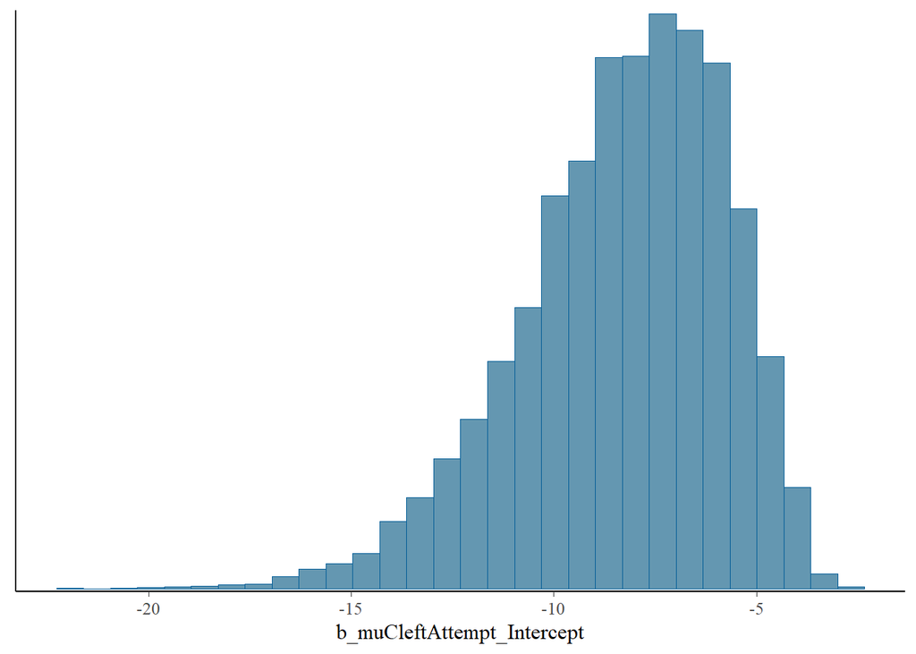

```r
#too much histograms if no selections
# only show population-level effects in the plots
mcmc_plot(brm_model_full, type = "hist", variable = "b_muCleftAttempt_Intercept", regex = TRUE)
```

#### 5. Do the chains exhibit a strong degree of autocorrelation?

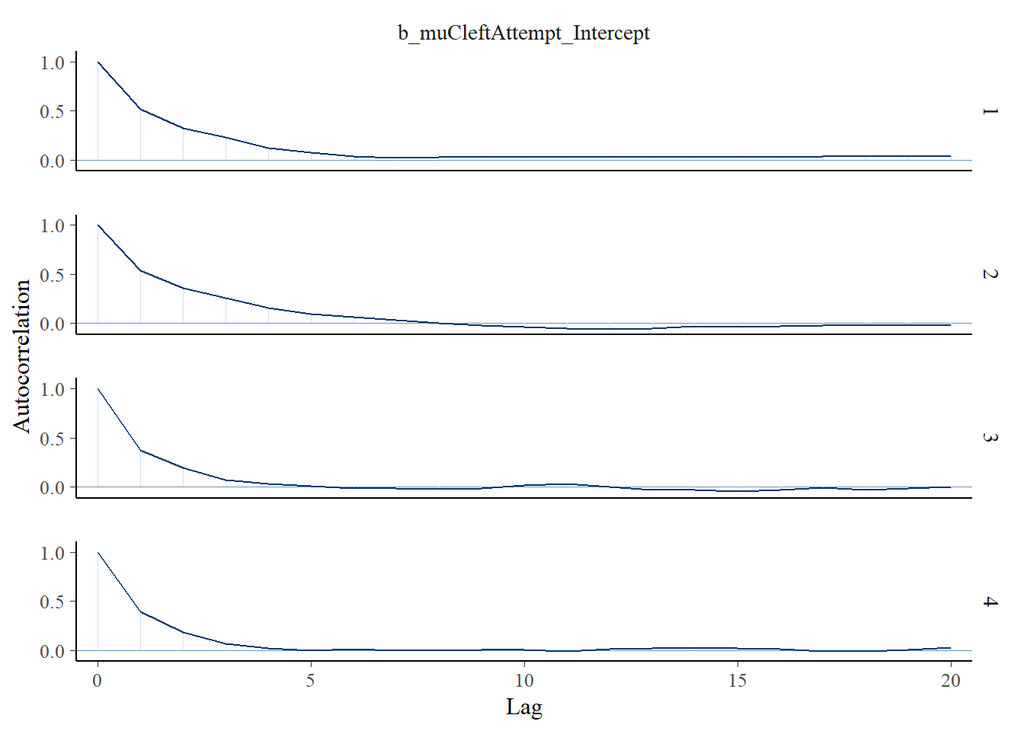

```r
mcmc_plot(brm_model_full, type = "acf", variable = "b_muCleftAttempt_Intercept", regex = TRUE)
```

#### 6. Do the posterior distributions make substantive sense?

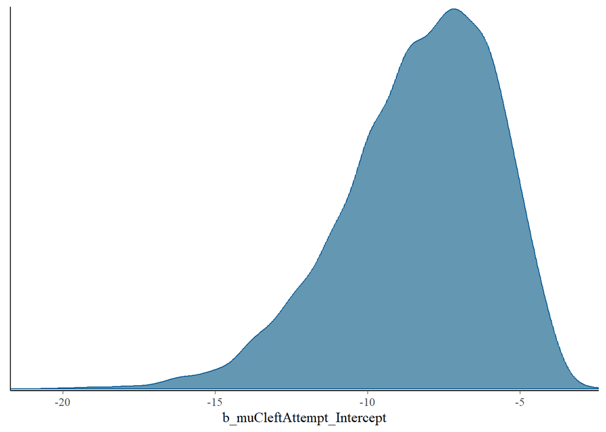

```r
mcmc_plot(brm_model_full, type = "dens", variable = "b_muCleftAttempt_Intercept", regex = TRUE)
```

#### 7. Do different specification of the variance priors influence the results?

```r
priors_larger_var <- priors

priors_larger_var$prior[priors_larger_var$class =="b" &
                          priors_larger_var$coef == ""] <- "normal(0,20)"

job::job({
  brm(
    model_formula,
    data = dt,
    family = categorical(),
    prior = priors_larger_var,
    iter = 4000,
    warmup = 1000,
    cores = 4,
    control = list(adapt_delta = 0.95),
    file = "brm_model_full_larger_var"
)})
```

```r
brm_model_full_larger_var <- readRDS("brm_model_full_larger_var.rds")

results_brm_model_full_larger_var <- get_result_table(brm_model_full_larger_var)
```

```r
sort(get_relative_bias_PD(results_brm_model_full,
                     results_brm_model_full_larger_var))
```

```
 [1] -11.65632981  -5.52375501  -5.29781044  -4.66049921  -4.34636684
 [6]  -2.80373832  -2.23667513  -2.02156334  -1.99853049  -1.89193280
[11]  -1.80037903  -1.58749692  -1.40518615  -1.39178845  -1.34843581
[16]  -1.30111524  -1.08158947  -1.04452278  -0.96185375  -0.71942446
[21]  -0.57667663  -0.47958522  -0.43103448  -0.42250618  -0.22387180
[26]  -0.19642303  -0.19049529  -0.13053519  -0.10062387  -0.06007209
[31]  -0.03006615  -0.02023063  -0.02000600  -0.01003915  -0.01000300
[36]  -0.01000100  -0.01000100   0.00000000   0.00000000   0.00000000
[41]   0.00000000   0.00000000   0.00000000   0.00000000   0.00000000
[46]   0.00000000   0.00000000   0.00000000   0.00000000   0.00000000
[51]   0.00000000   0.00000000   0.00000000   0.00000000   0.00000000
[56]   0.01000000   0.05120328   0.11340440   0.12516950   0.14250814
[61]   0.15116396   0.29097963   0.30076863   0.37298387   0.38958376
[66]   0.48113723   0.56806445   0.61378112   0.66791901   0.66851459
[71]   0.74883930   0.75584883   1.20178042   1.20606478   1.28366123
[76]   1.59543326   1.65863067   1.71270718   2.10765732   2.32001665
[81]   2.38431151   2.49747730   2.97005095   4.03722262   4.39184372
[86]   4.86139012   5.06867233   5.24871982   5.25946704   5.30623380
[91]   5.98499389   6.81360202   6.96134090   7.59129565   7.99161535
[96]  10.23298310
```

We have a few higher values here, we can check if thsi relative difference would have an impact on the interpretation of the data when $> |5|%$

```r
compare_results <- cbind.data.frame(results_brm_model_full[c(1:3,5)],
                                    results_brm_model_full_larger_var[c(1:3,5)],
                                    rel_bias_PD = get_relative_bias_PD(results_brm_model_full,
                                                    results_brm_model_full_larger_var))

compare_results[abs(compare_results$rel_bias_PD)>5,]
```

|  | Estimate | l-95% CI | u-95% CI | PD | Estimate | l-95% CI | u-95% CI | PD | rel_bias_PD |
| --- | --- | --- | --- | --- | --- | --- | --- | --- | --- |
| muCleftAttempt_Age_group3yDo | -3.00 | -13.06 | 4.81 | 73.31% | -4.83 | -24.01 | 10.12 | 69.42% | 5.306234 |
| muCleftAttempt_Age_group3yDo:ConditionAdjunct | -1.35 | -17.70 | 12.62 | 54.68% | -1.66 | -31.80 | 23.87 | 51.81% | 5.248720 |
| muCleftAttempt_Age_group4yDo:ConditionAdjunct | 2.50 | -4.89 | 11.54 | 71.3% | 4.03 | -9.69 | 21.66 | 67.55% | 5.259467 |
| muCleftAttempt_Age_group3yDo:ConditionDirect_object | 4.96 | -2.92 | 14.99 | 87.56% | 6.80 | -8.09 | 25.96 | 78.6% | 10.232983 |
| muCleftAttempt_Age_group4yDo:ConditionIndirect_object | 3.73 | -4.14 | 13.17 | 79.96% | 5.66 | -8.71 | 23.62 | 73.89% | 7.591296 |
| muIdentSentence_ConditionDirect_object | 0.20 | -1.43 | 1.69 | 61.16% | 0.15 | -1.49 | 1.68 | 58.06% | 5.068672 |
| muIdentSentence_ConditionIndirect_object | -0.77 | -3.82 | 1.55 | 69.88% | -0.99 | -4.48 | 1.53 | 73.74% | -5.523755 |
| muIdentSentence_Age_group5yDo:ConditionIndirect_object | 0.66 | -2.38 | 3.98 | 65.31% | 0.87 | -2.34 | 4.59 | 68.77% | -5.297810 |
| muOther_ConditionIndirect_object | -0.83 | -9.77 | 6.50 | 54.82% | -2.77 | -20.15 | 11.56 | 61.21% | -11.656330 |
| muOther_Age_group3yDo:ConditionAdjunct | 3.01 | -4.47 | 11.82 | 76.33% | 4.44 | -9.61 | 21.65 | 70.23% | 7.991615 |

[output cut: 3 more lines]

```r
priors_smaller_var <- priors

priors_smaller_var$prior[priors_smaller_var$class =="b" &
                          priors_smaller_var$coef == ""] <- "normal(0,2)"


job::job({
  brm(
    model_formula,
    data = dt,
    family = categorical(),
    prior = priors_smaller_var,
    iter = 4000,
    warmup = 1000,
    cores = 4,
    control = list(adapt_delta = 0.95),
    file = "brm_model_full_smaller_var"
)})
```

```r
brm_model_full_smaller_var <- readRDS(file = "brm_model_full_smaller_var.rds")

results_brm_model_full_smaller_var <- get_result_table(brm_model_full_smaller_var)
```

```r
sort(get_relative_bias_PD(results_brm_model_full,
                     results_brm_model_full_smaller_var))
```

```
 [1] -28.87632251 -27.53433617 -19.28468492 -18.52864422 -17.30197351
 [6] -17.09944751 -16.73586256 -16.02015113 -15.74219307 -15.48940464
[11] -14.15707854 -13.81957774 -13.65920512 -11.35831382 -10.11869436
[16] -10.07012623  -9.79119639  -8.82553540  -8.61122271  -8.42423225
[21]  -8.39429407  -7.05260740  -6.79001571  -6.01735776  -5.41008856
[26]  -4.94259158  -4.67862315  -3.73962711  -3.47301484  -3.14337133
[31]  -3.12043415  -2.72148234  -2.39619913  -2.37203496  -2.05106739
[36]  -1.46606520  -1.36200717  -0.88996764  -0.62500000  -0.58450066
[41]  -0.37863951  -0.29180922  -0.25097882  -0.16035278   0.00000000
[46]   0.00000000   0.00000000   0.00000000   0.00000000   0.00000000
[51]   0.00000000   0.00000000   0.00000000   0.00000000   0.00000000
[56]   0.00000000   0.01000000   0.01004117   0.02000000   0.02000000
[61]   0.03000000   0.03000000   0.06000000   0.13000000   0.33003300
[66]   0.48014404   0.58913633   0.61006101   1.01592115   1.20997184
[71]   2.25270324   2.44299674   3.00090027   3.31140848   3.40886102
[76]   3.42891518   4.66246252   4.86453202   5.71929101   6.36805953
[81]   7.95852236   8.19094404  10.46015958  10.79467157  11.34289439
[86]  11.35929464  12.05031742  13.19222250  14.33542102  14.43762169
[91]  16.42197669  18.28806064  18.73413706  19.13061100  29.97728211
[96]  39.74086661
```

That’s a lot. It may indicate that less variance in our prior is bad here.

```r
compare_results <- cbind.data.frame(results_brm_model_full[c(1:3,5)],
                                    results_brm_model_full_smaller_var[c(1:3,5)],
                                    rel_bias_PD = get_relative_bias_PD(results_brm_model_full,
                                                    results_brm_model_full_smaller_var))

head(compare_results[abs(compare_results$rel_bias_PD)>5,])
```

|  | Estimate | l-95% CI | u-95% CI | PD | Estimate | l-95% CI | u-95% CI | PD | rel_bias_PD |
| --- | --- | --- | --- | --- | --- | --- | --- | --- | --- |
| muCleftAttempt_Age_group3yDo | -3.00 | -13.06 | 4.81 | 73.31% | -0.85 | -2.95 | 1.01 | 79.78% | -8.825535 |
| muCleftAttempt_ConditionAdjunct | -2.41 | -11.33 | 4.89 | 70.13% | -0.85 | -2.79 | 0.90 | 81.17% | -15.742193 |
| muCleftAttempt_ConditionIndirect_object | -2.17 | -11.69 | 5.52 | 66.77% | -0.23 | -2.35 | 1.72 | 57.13% | 14.437622 |
| muCleftAttempt_Age_group3yDo:ConditionAdjunct | -1.35 | -17.70 | 12.62 | 54.68% | -0.48 | -4.05 | 2.75 | 59.27% | -8.394294 |
| muCleftAttempt_Age_group4yDo:ConditionAdjunct | 2.50 | -4.89 | 11.54 | 71.3% | 0.83 | -1.23 | 2.93 | 78.48% | -10.070126 |
| muCleftAttempt_Age_group5yDo:ConditionAdjunct | 2.37 | -4.93 | 11.37 | 69.85% | 0.90 | -0.97 | 2.91 | 81.54% | -16.735863 |

Yes it would change our interpretation in quite a few cases. We can show graphically why a smaller variance might be bad !

##### Showing the difference in priors

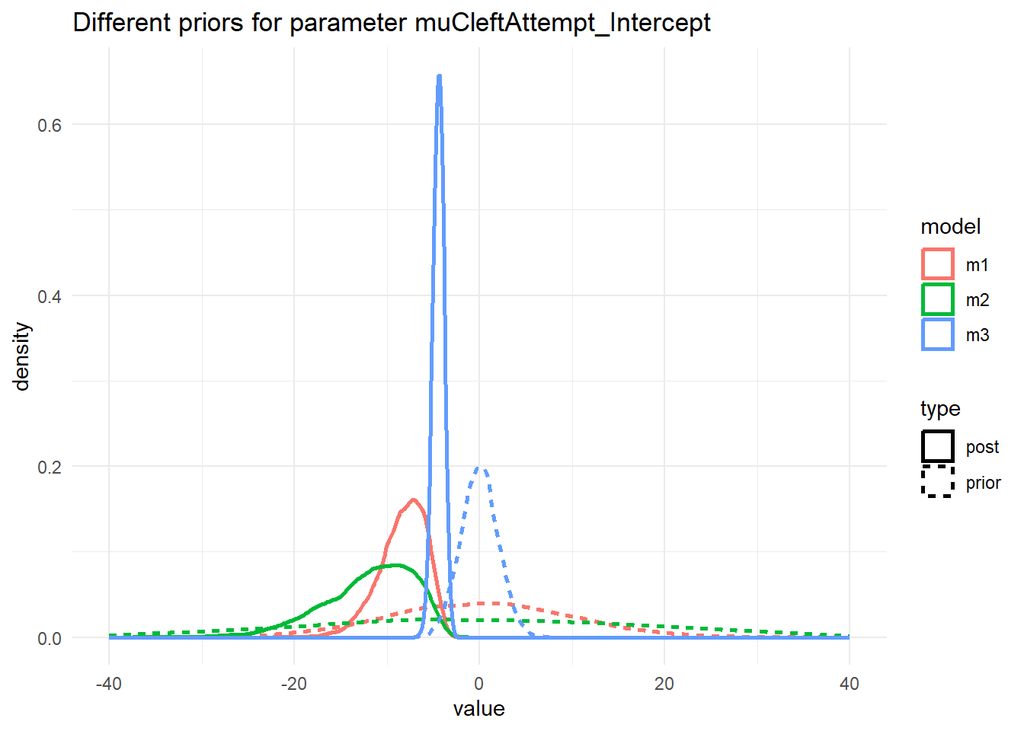

```r
m1prior <- rnorm(12000, mean = 0, sd = 10)
m1post <- as_draws_df(brm_model_full)
m2prior <- rnorm(12000, mean = 0, sd = 20)
m2post <- as_draws_df(brm_model_full_larger_var)
m3prior <- rnorm(12000, mean = 0, sd = 2)
m3post <- as_draws_df(brm_model_full_smaller_var)



#showing density plots for a1

#make a data frame and get it in shape for ggplot
a1df <- data.frame(m1_prior = m1prior,
                   m1_post = m1post$b_muCleftAttempt_Intercept,
                   m2_prior = m2prior,
                   m2_post =  m2post$b_muCleftAttempt_Intercept,
                   m3_prior = m3prior,
                   m3_post =  m3post$b_muCleftAttempt_Intercept) %>%
        tidyr::pivot_longer(cols = everything(), names_to = c("model","type"), names_pattern = "(.*)_(.*)", values_to = "value")
# make plot
p1 <- a1df %>%
  ggplot() +
  geom_density(aes(x = value, color = model, linetype = type), linewidth = 1) +
  theme_minimal()+
  ggtitle("Different priors for parameter muCleftAttempt_Intercept")+
  xlim(-40,40)

p1
```

For a simple parameter, all the posterior go in the same direction.

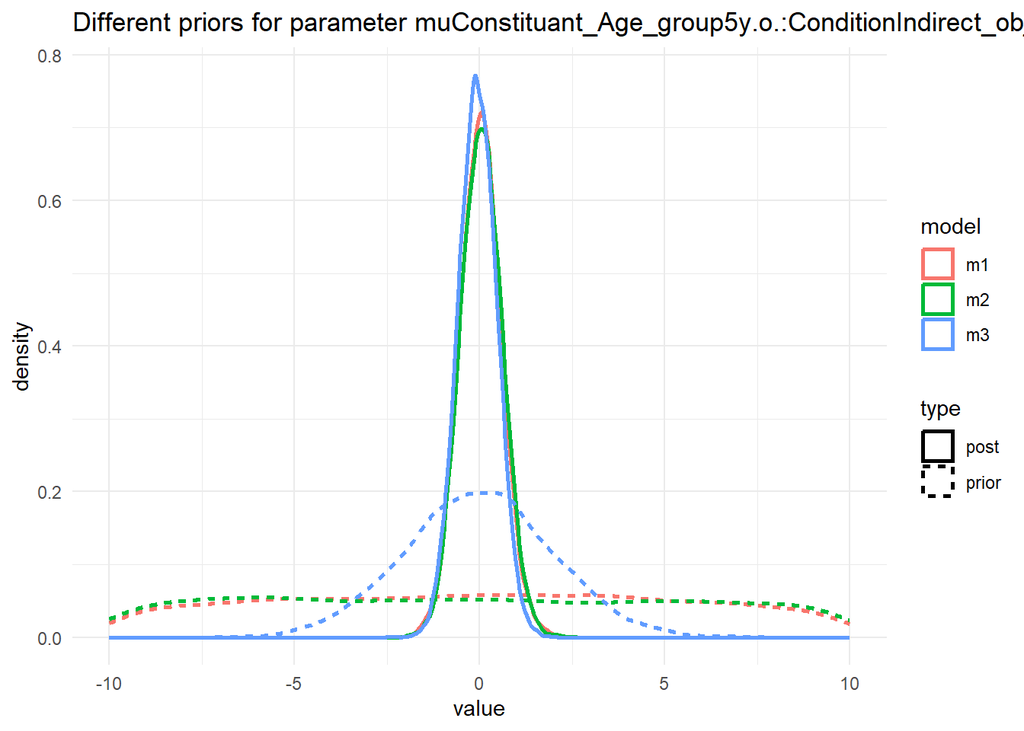

```r
#make a data frame and get it in shape for ggplot
a2df <- data.frame(m1_prior = m1prior,
                   m1_post = m1post$`b_muConstituant_Age_group5yDo:ConditionIndirect_object`,
                   m2_prior = m2prior,
                   m2_post =  m2post$`b_muConstituant_Age_group5yDo:ConditionIndirect_object`,
                   m3_prior = m3prior,
                   m3_post =  m3post$`b_muConstituant_Age_group5yDo:ConditionIndirect_object`) %>%
        tidyr::pivot_longer(cols = everything(), names_to = c("model","type"), names_pattern = "(.*)_(.*)", values_to = "value")
# make plot
p2 <- a2df %>%
  ggplot() +
  geom_density(aes(x = value, color = model, linetype = type), linewidth = 1) +
  theme_minimal()+
  ggtitle("Different priors for parameter muConstituant_Age_group5y.o.:ConditionIndirect_object")+
  xlim(-10,10)

p2
```

#### 8. Is there a notable effect of the prior when compared with non-informative priors ?

```r
brm_model_full_wo_priors <- readRDS("brm_model_full_wo_priors.rds")

results_brm_model_full_wo_priors <- get_result_table(brm_model_full_wo_priors)
sort(get_relative_bias_PD(results_brm_model_full,
                     results_brm_model_full_wo_priors))
```

```
 [1] -92.52984213 -74.44551591 -66.21916429 -64.42660150 -55.08528111
 [6] -53.72535334 -51.23104517 -48.36795252 -46.87729611 -46.37002342
[11] -44.86455164 -43.43274112 -42.67315398 -42.45497200 -38.24473280
[16] -36.37975720 -35.71963457 -34.96891052 -34.84358145 -30.87016575
[21] -29.55281918 -28.67810821 -28.20043892 -26.13521695 -24.68513854
[26] -23.06177701 -19.97600480 -18.01636569 -17.82726523 -17.07513057
[31] -16.52681503 -14.51872272 -13.40440009 -12.96898449 -11.39578924
[36]  -9.49623625  -9.34937124  -9.30156301  -7.77023386  -6.99830265
[41]  -6.83484528  -6.79196924  -4.36234607  -4.30791697  -3.28444536
[46]  -2.64353573  -2.60673235  -2.40655402  -1.56758958  -0.80645161
[51]  -0.64738013  -0.62386798  -0.39152696  -0.22048507  -0.04294918
[56]  -0.01000100   0.00000000   0.00000000   0.00000000   0.00000000
[61]   0.00000000   0.00000000   0.00000000   0.02000000   0.02000000
[66]   0.04548901   0.12000000   0.12000000   0.18537003   0.74192902
[71]   0.83000000   1.14034210   1.93548387   2.00000000   5.07050705
[76]   6.17271228   6.68737737   6.93338708   9.90000000  10.86448598
[81]  11.23595506  11.32016954  11.64251697  15.37283724  15.68430565
[86]  22.50000000  24.82979575  26.70000000  27.59893377  29.51751334
[91]  32.69456854  38.86165850  39.16171768  46.05000000  46.45000000
[96]  46.83000000
```

Yes there is, but in this case we know why we are not using non-informative priors.

#### 9. Are the results stable from a sensitivity analysis ?

You should be able to do this by setting up an hyperprior, but since I had a hard time setting the prior the traditional *brms* way, I’ll settle on two simple Bayesian model with a change of means.

```r
#don't run this unless necessary (takes time)
priors_lower_mean <- priors


priors_lower_mean$prior[priors_lower_mean$class =="b" &
                        priors_lower_mean$coef == ""] <- "normal(-10,10)"


#this takes a while to run (20 mins ?)
#use the job package to make it run in the background
job::job({
  brm(
    model_formula,
    data = dt,
    family = categorical(),
    prior = priors_lower_mean,
    iter = 4000,
    warmup = 1000,
    cores = 4,
    control = list(adapt_delta = 0.95),
    file = "brm_model_full_lower_mean"
)})
```

```r
brm_model_full_lower_mean <- readRDS("brm_model_full_lower_mean.rds")

results_brm_model_full_lower_mean <- get_result_table(brm_model_full_lower_mean)

sort(get_relative_bias_PD(results_brm_model_full,
                     results_brm_model_full_lower_mean))
```

```
 [1] -63.93442623 -53.67593270 -49.83423486 -43.20887005 -12.25138122
 [6] -11.08971891 -10.35300684 -10.17876687  -8.66579464  -7.75964392
[11]  -5.52403011  -5.37177986  -5.23461150  -3.81508637  -3.75524895
[16]  -3.41144039  -2.04968252  -1.26845271  -1.24256585  -1.17929451
[21]  -0.94837806  -0.76430490  -0.76414705  -0.50235801  -0.50179211
[26]  -0.43570777  -0.33256072  -0.20161290  -0.14087342  -0.14054814
[31]  -0.06013229   0.00000000   0.00000000   0.00000000   0.00000000
[36]   0.00000000   0.00000000   0.00000000   0.00000000   0.00000000
[41]   0.00000000   0.00000000   0.00000000   0.00000000   0.00000000
[46]   0.00000000   0.01000000   0.01000000   0.01000000   0.01000100
[51]   0.02000000   0.11003301   0.11045286   0.12001200   0.14004201
[56]   0.32038446   0.52135552   0.67733990   1.45561889   1.64879628
[61]   1.80915952   2.66900247   3.25440701   4.27135678   4.78428022
[66]   5.42135753   6.23724200   6.59611125   6.79582261   6.83399263
[71]   7.12131756   7.43490044   7.83731890   8.37056196   8.94390384
[76]   9.93702771  10.03236246  10.30160595  10.31203964  10.51810237
[81]  10.80689555  11.76371874  11.79520415  12.76967005  13.18698673
[86]  13.21087436  17.28678610  18.37168584  20.47687672  21.98773706
[91]  22.07957111  22.23573939  22.71417741  23.29277022  23.60448808
[96]  24.95132545
```

```r
compare_results <- cbind.data.frame(results_brm_model_full[c(1:3,5)],
                                    results_brm_model_full_lower_mean[c(1:3,5)],
                                    rel_bias_PD = get_relative_bias_PD(results_brm_model_full,
                                                    results_brm_model_full_lower_mean))

head(compare_results[abs(compare_results$rel_bias_PD)>5,])
```

|  | Estimate | l-95% CI | u-95% CI | PD | Estimate | l-95% CI | u-95% CI | PD | rel_bias_PD |
| --- | --- | --- | --- | --- | --- | --- | --- | --- | --- |
| muCleftAttempt_Age_group3yDo | -3.00 | -13.06 | 4.81 | 73.31% | -2.32 | -12.10 | 5.13 | 68.3% | 6.833993 |
| muCleftAttempt_ConditionAdjunct | -2.41 | -11.33 | 4.89 | 70.13% | -0.73 | -9.08 | 5.88 | 54.71% | 21.987737 |
| muCleftAttempt_ConditionIndirect_object | -2.17 | -11.69 | 5.52 | 66.77% | -0.34 | -8.95 | 6.56 | 50.11% | 24.951325 |
| muCleftAttempt_Age_group3yDo:ConditionAdjunct | -1.35 | -17.70 | 12.62 | 54.68% | -8.64 | -26.62 | 6.52 | 84.03% | -53.675933 |
| muCleftAttempt_Age_group4yDo:ConditionAdjunct | 2.50 | -4.89 | 11.54 | 71.3% | 0.72 | -6.07 | 9.11 | 54.47% | 23.604488 |
| muCleftAttempt_Age_group5yDo:ConditionAdjunct | 2.37 | -4.93 | 11.37 | 69.85% | 0.63 | -6.04 | 9.09 | 53.58% | 23.292770 |

Does show some variation, but the bigger picture (CrI) stays mostly the same.

```r
#don't run this unless necessary (takes time)
priors_higher_mean <- priors


priors_higher_mean$prior[priors_higher_mean$class =="b" &
                        priors_higher_mean$coef == ""] <- "normal(10,10)"


#this takes a while to run (20 mins ?)
#use the job package to make it run in the background
job::job({
  brm(
    model_formula,
    data = dt,
    family = categorical(),
    prior = priors_higher_mean,
    iter = 4000,
    warmup = 1000,
    cores = 4,
    control = list(adapt_delta = 0.95),
    file = "brm_model_full_higher_mean"
)})
```

```r
brm_model_full_higher_mean <- readRDS("brm_model_full_higher_mean.rds")

results_brm_model_full_higher_mean <- get_result_table(brm_model_full_higher_mean)

sort(get_relative_bias_PD(results_brm_model_full,
                     results_brm_model_full_higher_mean))
```

```
 [1] -61.35004822 -39.02706657 -34.18251614 -24.42759666 -23.75045604
 [6] -23.38197970 -22.31925555 -21.94495936 -21.20617111 -19.66451999
[11] -18.18058935 -17.48170966 -16.99005381 -16.81212678 -15.78671558
[16] -14.78555305 -13.72394188 -12.92163115 -12.32916973 -11.90595298
[21] -11.17123407 -10.59327709 -10.07441328  -9.01763224  -8.64342603
[26]  -8.52211435  -8.48906273  -7.64744005  -6.73642135  -6.22016096
[31]  -5.91796579  -5.74698499  -5.48596613  -4.87804878  -4.36606940
[36]  -3.89113564  -3.66208906  -3.08628791  -2.40977615  -1.59591113
[41]  -1.34394707  -1.14385820  -0.85180624  -0.61703419  -0.39698697
[46]  -0.24098805  -0.21054742  -0.10012014  -0.03000900  -0.03000900
[51]  -0.01000100  -0.01000100   0.00000000   0.00000000   0.00000000
[56]   0.00000000   0.00000000   0.00000000   0.00000000   0.00000000
[61]   0.00000000   0.00000000   0.00000000   0.00000000   0.00000000
[66]   0.00000000   0.00000000   0.00000000   0.00000000   0.01000000
[71]   0.02000000   0.04008819   0.15058729   0.21162955   0.26345121
[76]   0.30187160   0.37174721   0.52419355   0.55225149   0.96262161
[81]   1.04572483   1.42256709   1.54926668   1.71154248   2.50410060
[86]   3.83201515   5.33893221   5.41006203   5.50515720   5.81483350
[91]   6.50839606   8.31381733   8.86005302   9.22848665  13.27665141
[96]  15.22099448
```

```r
compare_results <- cbind.data.frame(results_brm_model_full[c(1:3,5)],
                                    results_brm_model_full_higher_mean[c(1:3,5)],
                                    rel_bias_PD = get_relative_bias_PD(results_brm_model_full,
                                                    results_brm_model_full_higher_mean))

head(compare_results[abs(compare_results$rel_bias_PD)>5,])
```

|  | Estimate | l-95% CI | u-95% CI | PD | Estimate | l-95% CI | u-95% CI | PD | rel_bias_PD |
| --- | --- | --- | --- | --- | --- | --- | --- | --- | --- |
| muCleftAttempt_Age_group3yDo | -3.00 | -13.06 | 4.81 | 73.31% | -3.78 | -14.14 | 4.71 | 77.87% | -6.220161 |
| muCleftAttempt_ConditionAdjunct | -2.41 | -11.33 | 4.89 | 70.13% | -4.99 | -14.90 | 3.41 | 85.52% | -21.944959 |
| muCleftAttempt_ConditionIndirect_object | -2.17 | -11.69 | 5.52 | 66.77% | -4.13 | -14.26 | 4.29 | 79.9% | -19.664520 |
| muCleftAttempt_Age_group3yDo:ConditionAdjunct | -1.35 | -17.70 | 12.62 | 54.68% | 4.98 | -10.38 | 18.74 | 76.02% | -39.027067 |
| muCleftAttempt_Age_group4yDo:ConditionAdjunct | 2.50 | -4.89 | 11.54 | 71.3% | 5.18 | -3.38 | 15.11 | 86.42% | -21.206171 |
| muCleftAttempt_Age_group5yDo:ConditionAdjunct | 2.37 | -4.93 | 11.37 | 69.85% | 5.02 | -3.45 | 15.01 | 85.44% | -22.319256 |

Basically pushes the results a bit more towards the left or right, so slightly different CrI that are close to 0 are affected.

#### 10. Is the Bayesian way of interpreting and reporting model results used?

To report things from a Bayesian analysis, you can check the BARG guidelines J. K. Kruschke (2021)

Or check an article that I think made a good job of showing Bayesian results Levshina and Lorenz (2022)

### Other ways to plot results

Of different priors

```r
combined <- rbind(bayesplot::mcmc_intervals_data(m1post),
                  bayesplot::mcmc_intervals_data(m2post),
                  bayesplot::mcmc_intervals_data(m3post))

combined$model <- rep(c("sd 10", "sd 20", "sd 2"), each = ncol(m1post)-3)
```

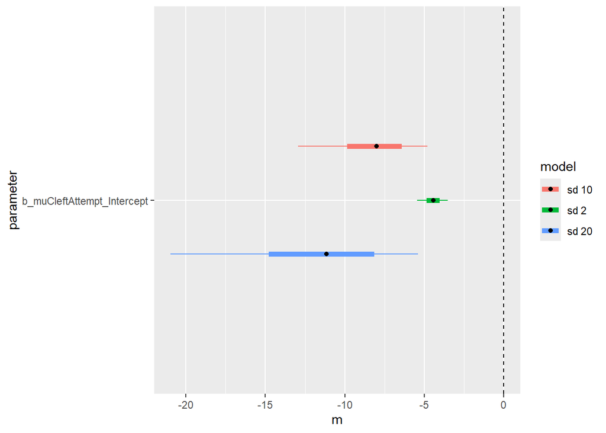

```r
combined |>
  filter(parameter %in% c("b_muCleftAttempt_Intercept",
                          "b_muConstituant_Age_group5y.o.:ConditionIndirect_object")) |>
  ggplot(aes(x = m, y = parameter, color = model)) +
  geom_linerange(aes(xmin = l, xmax = h), position = position_dodge2(width = 0.5, reverse = T), linewidth=2)+
  geom_linerange(aes(xmin = ll, xmax = hh), position =  position_dodge2(width = 0.5, reverse = T))+
  geom_point(aes(fill = model), position = position_dodge2(width = 0.5, reverse = T), color="black")+
  geom_vline(xintercept=0,linetype="dashed")
```

Of multiple parameters estimates

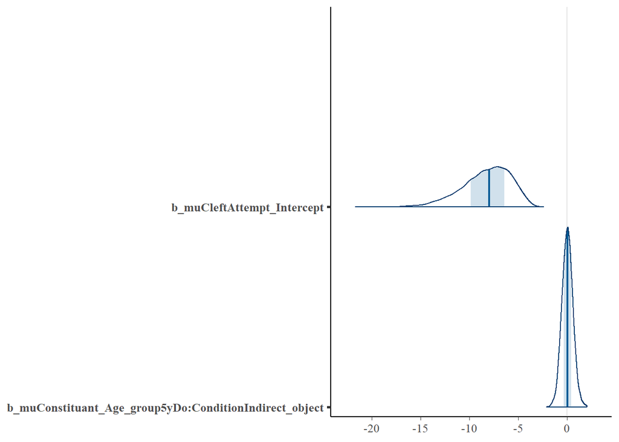

```r
posterior_draws <- brms::as_draws_matrix(brm_model_full)[,c("b_muCleftAttempt_Intercept",
                                                            "b_muConstituant_Age_group5yDo:ConditionIndirect_object")]
bayesplot::mcmc_areas(posterior_draws)
```

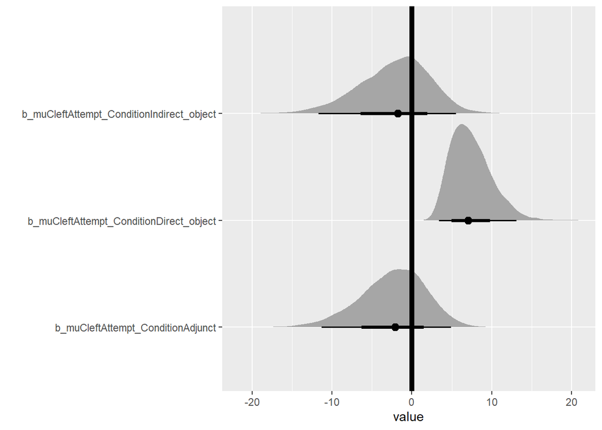

```r
brm_model_full |>
  tidybayes::tidy_draws() |>
  select(starts_with("b_muCleftAttempt_Con")) |>
  # rename(reaction = b_conditionreaction,
  #        discrimination = b_conditiondiscrimination) |>
  tidyr::pivot_longer(cols = everything()) |>
  ggplot(aes(x = value, y = name)) +
  tidybayes::stat_halfeye(#fill = project_colors[1]
                          ) +
  ylab("") +
  geom_vline(aes(xintercept = 0), #color = project_colors[2],
             size = 2)
```

If you want the distributions of the individual items.

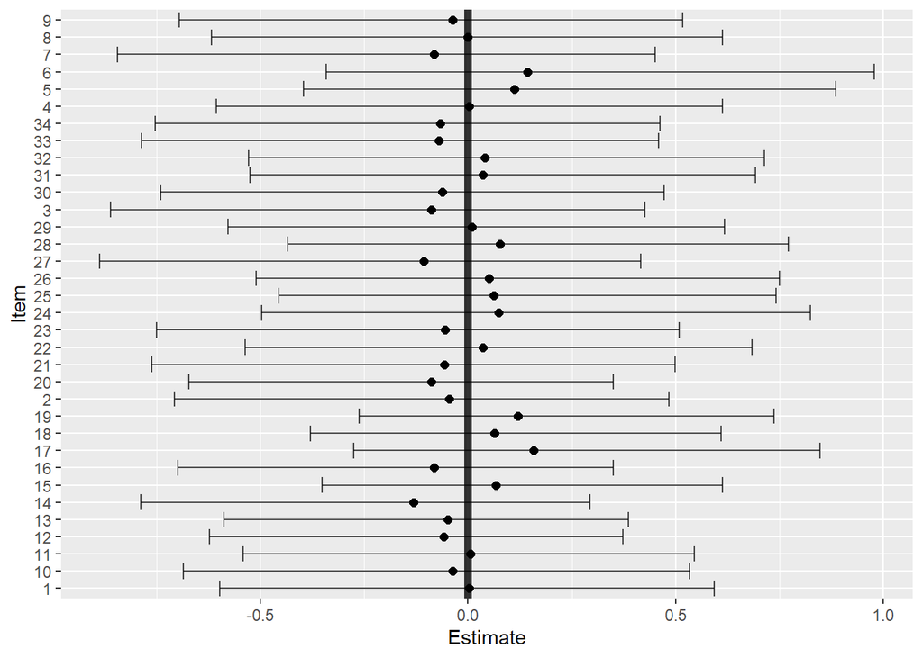

```r
ranef(brm_model_full)$Item[,,"muCleftAttempt_Intercept"] |>
  as.data.frame() |>
  tibble::rownames_to_column("Item") |>
  ggplot(aes(y = Item, x = Estimate)) +
  geom_errorbar(aes(xmin = `Q2.5`, xmax = `Q97.5`),
                #color = project_colors[6],
                alpha = 0.7)+
  geom_vline(aes(xintercept = 0),# color = project_colors[1],
             size = 2, alpha = 0.8) +
  geom_point(#color = project_colors[2],
             size = 2)
```

## References

Albert, A., and J. A. Anderson. 1984. “On the Existence of Maximum Likelihood Estimates in Logistic Regression Models.” *Biometrika* 71 (1): 1–10. https://doi.org/10.1093/biomet/71.1.1.

Bürkner, Paul-Christian. 2017. “Brms: An r Package for Bayesian Multilevel Models Using Stan” 80. https://doi.org/10.18637/jss.v080.i01.

“FAQ What Is Complete or Quasi-Complete Separation in Logistic/Probit Regression and How Do We Deal with Them?” n.d. https://stats.oarc.ucla.edu/other/mult-pkg/faq/general/faqwhat-is-complete-or-quasi-complete-separation-in-logisticprobit-regression-and-how-do-we-deal-with-them/.

Gelman, Andrew, Aleks Jakulin, Maria Grazia Pittau, and Yu-Sung Su. 2008. “A Weakly Informative Default Prior Distribution for Logistic and Other Regression Models.” *The Annals of Applied Statistics* 2 (4): 1360–83. https://doi.org/10.1214/08-AOAS191.

Kruschke, John. 2014. *Doing Bayesian Data Analysis*. https://shop.elsevier.com/books/doing-bayesian-data-analysis/kruschke/978-0-12-405888-0.

Kruschke, John K. 2021. “Bayesian Analysis Reporting Guidelines.” *Nature Human Behaviour* 5 (10): 1282–91. https://doi.org/10.1038/s41562-021-01177-7.

Levshina, Natalia, and David Lorenz. 2022. “Communicative Efficiency and the Principle of No Synonymy: Predictability Effects and the Variation of *Want to* and *Wanna*.” *Language and Cognition* 14 (2): 249–74. https://doi.org/10.1017/langcog.2022.7.

Link, William A., and Mitchell J. Eaton. 2012. “On Thinning of Chains in MCMC.” *Methods in Ecology and Evolution* 3 (1): 112–15. https://doi.org/10.1111/j.2041-210X.2011.00131.x.

Makowski, Dominique, Mattan S. Ben-Shachar, S. H. Annabel Chen, and Daniel Lüdecke. 2019. “Indices of Effect Existence and Significance in the Bayesian Framework.” *Frontiers in Psychology* 10 (December). https://doi.org/10.3389/fpsyg.2019.02767.

Mansournia, Mohammad Ali, Angelika Geroldinger, Sander Greenland, and Georg Heinze. 2018. “Separation in Logistic Regression: Causes, Consequences, and Control.” *American Journal of Epidemiology* 187 (4): 864–70. https://doi.org/10.1093/aje/kwx299.

*Notation*. n.d. https://cran.r-project.org/web/packages/brms/vignettes/brms_families.html.

Peng, Roger D. n.d. *7.4 Monitoring Convergence | Advanced Statistical Computing*. https://bookdown.org/rdpeng/advstatcomp/monitoring-convergence.html.

“Rank-Normalization, Folding, and Localization: An Improved r for Assessing Convergence of MCMC (Online Appendix).” n.d. https://avehtari.github.io/rhat_ess/rhat_ess.html.

Schoot, Rens van de, Sarah Depaoli, Ruth King, Bianca Kramer, Kaspar Märtens, Mahlet G. Tadesse, Marina Vannucci, et al. 2021. “Bayesian Statistics and Modelling.” *Nature Reviews Methods Primers* 1 (1): 1–26. https://doi.org/10.1038/s43586-020-00001-2.

Vehtari, Aki, Andrew Gelman, Daniel Simpson, Bob Carpenter, and Paul-Christian Bürkner. 2021. “Rank-Normalization, Folding, and Localization: An Improved $R$ for Assessing Convergence of MCMC.” *Bayesian Analysis* 16 (2). https://doi.org/10.1214/20-BA1221.

“WAMBS Checklist in r (Using Brms).” n.d. https://www.rensvandeschoot.com/tutorials/wambs-checklist-in-r-using-brms/.